# 291JAssignment2

## Necessary Library Installations and Imports

Folktables - Python library that allows us to access US Census Datasets for different states that consists of mulltiple sensitive attributes.  
Polars - Python Data Manipulation and Handling library. Similar to Pandas

```python
# !pip install folktables
# !pip install polars
# ! pip install xgboost
# !pip install lightgbm
```

```python
import folktables
import pandas as pd
import polars as pl
import numpy as np
import matplotlib.pyplot as plt
from folktables import ACSDataSource, ACSIncome, ACSPublicCoverage, generate_categories
import matplotlib.colors as mcolors
import polars as pl
import pandas as pd
import numpy as np
import matplotlib.pyplot as plt
import seaborn as sns
from sklearn.naive_bayes import GaussianNB
from sklearn.svm import SVC
from sklearn.model_selection import train_test_split
from sklearn.preprocessing import OneHotEncoder, StandardScaler, LabelEncoder
from sklearn.compose import ColumnTransformer
from sklearn.pipeline import Pipeline
from sklearn.linear_model import LogisticRegression
from sklearn.metrics import classification_report, accuracy_score,confusion_matrix
from sklearn.tree import DecisionTreeClassifier
from sklearn.ensemble import RandomForestClassifier,VotingClassifier,BaggingClassifier
from xgboost import XGBClassifier
from lightgbm import LGBMClassifier
from fairlearn.metrics import demographic_parity_difference
from sklearn.base import clone
from sklearn.model_selection import GridSearchCV,RandomizedSearchCV
from fairlearn.reductions import ExponentiatedGradient, DemographicParity,GridSearch
from sklearn.pipeline import make_pipeline
```

Data is being loaded through the **folk-tables** module. We are going to perform our Fairness Metrics Analysis on the **Public Health Coverage** Data from the US Census 2018 of 5 different US states

Downloading in the following cell takes longer to run,the dataset has been downloaded and saved as CSV files and commented out.

```python
data_source = ACSDataSource(survey_year='2018', horizon='1-Year', survey='person')

# ca_data = data_source.get_data(states=["CA","MA","TX", "NY", "GA"], download=True)
# print(list(ca_data.head().columns))

# ca_features, ca_labels, _ = ACSPublicCoverage.df_to_pandas(ca_data)
# ca_features.to_csv('data/multi_state_features.csv', index=False)
# ca_labels.to_csv('data/multi_state_labels.csv', index=False)

# Commented because already ran once and saved the CSV files
```

Column definitions can be accessed through the get definitions method in the data_source. Also, generate_categories specifies the column names available in the dataset.

```python
definition_df = data_source.get_definitions(download=True)
categories = generate_categories(features=ACSPublicCoverage.features, definition_df=definition_df)
```

```python
categories.keys()
```

```
dict_keys(['SCHL', 'MAR', 'SEX', 'DIS', 'ESP', 'CIT', 'MIG', 'MIL', 'ANC', 'NATIVITY', 'DEAR', 'DEYE', 'DREM', 'ESR', 'ST', 'FER', 'RAC1P'])
```

```python
features = pl.read_csv('data/multi_state_features.csv')
labels = pl.read_csv("data/multi_state_labels.csv")
```

```python
features.shape,labels.shape
```

```
((364726, 19), (364726, 1))
```

The dataset consists of **more than 300k rows with 19 columns**, excluding the label column.

```python
features.describe()
```

shape: (9, 20)

| statistic str | AGEP f64 | SCHL f64 | MAR f64 | SEX f64 | DIS f64 | ESP f64 | CIT f64 | MIG f64 | MIL f64 | ANC f64 | NATIVITY f64 | DEAR f64 | DEYE f64 | DREM f64 | PINCP f64 | ESR f64 | ST f64 | FER f64 | RAC1P f64 |
| --- | --- | --- | --- | --- | --- | --- | --- | --- | --- | --- | --- | --- | --- | --- | --- | --- | --- | --- | --- |
| "count" | 364726.0 | 364726.0 | 364726.0 | 364726.0 | 364726.0 | 364726.0 | 364726.0 | 364726.0 | 364726.0 | 364726.0 | 364726.0 | 364726.0 | 364726.0 | 364726.0 | 364726.0 | 364726.0 | 364726.0 | 364726.0 | 364726.0 |
| "null_count" | 0.0 | 0.0 | 0.0 | 0.0 | 0.0 | 0.0 | 0.0 | 0.0 | 0.0 | 0.0 | 0.0 | 0.0 | 0.0 | 0.0 | 0.0 | 0.0 | 0.0 | 0.0 | 0.0 |
| "mean" | 35.933569 | 16.554655 | 3.346452 | 1.565156 | 1.865258 | 0.300036 | 1.89032 | 1.325938 | 3.658231 | 1.76107 | 1.239635 | 1.980813 | 1.9744 | 1.931077 | 9577.727653 | 3.353663 | 24.817581 | 0.80549 | 2.630556 |
| "std" | 15.550484 | 4.126389 | 1.864167 | 0.495737 | 0.341449 | 1.217979 | 1.550974 | 0.731327 | 1.067738 | 1.129982 | 0.426861 | 0.137182 | 0.157939 | 0.253323 | 9969.563992 | 2.455723 | 17.82939 | 0.970503 | 2.692612 |
| "min" | 15.0 | 1.0 | 1.0 | 1.0 | 1.0 | 0.0 | 1.0 | 1.0 | 0.0 | 1.0 | 1.0 | 1.0 | 1.0 | 1.0 | -8300.0 | 0.0 | 6.0 | 0.0 | 1.0 |
| "25%" | 21.0 | 15.0 | 1.0 | 1.0 | 2.0 | 0.0 | 1.0 | 1.0 | 4.0 | 1.0 | 1.0 | 2.0 | 2.0 | 2.0 | 0.0 | 1.0 | 6.0 | 0.0 | 1.0 |
| "50%" | 33.0 | 17.0 | 5.0 | 2.0 | 2.0 | 0.0 | 1.0 | 1.0 | 4.0 | 1.0 | 1.0 | 2.0 | 2.0 | 2.0 | 6600.0 | 3.0 | 25.0 | 0.0 | 1.0 |
| "75%" | 50.0 | 19.0 | 5.0 | 2.0 | 2.0 | 0.0 | 3.0 | 1.0 | 4.0 | 2.0 | 1.0 | 2.0 | 2.0 | 2.0 | 18000.0 | 6.0 | 48.0 | 2.0 | 2.0 |
| "max" | 64.0 | 24.0 | 5.0 | 2.0 | 2.0 | 8.0 | 5.0 | 3.0 | 4.0 | 4.0 | 2.0 | 2.0 | 2.0 | 2.0 | 30000.0 | 6.0 | 48.0 | 2.0 | 9.0 |

This code uses the column definitions and aggregates them into a single data-structure to access the unique possible values and the definitions of the individual columns available in the dataset.

```python
column_details = {}
for col in features.columns:
    print(col,"---",definition_df[definition_df[1]==col].values[0][4])
    d  = {}
    d['Definition'] = definition_df[definition_df[1]==col].values[0][4]
    d['Possible Values'] = [col[6] for col in (definition_df[definition_df[1]==col].values.tolist()[1:])]
    column_details[col]=d
```

```
AGEP --- Age
SCHL --- Educational attainment
MAR --- Marital status
SEX --- Sex
DIS --- Disability recode
ESP --- Employment status of parents
CIT --- Citizenship status
MIG --- Mobility status (lived here 1 year ago)
MIL --- Military service
ANC --- Ancestry recode
NATIVITY --- Nativity
DEAR --- Hearing difficulty
DEYE --- Vision difficulty
DREM --- Cognitive difficulty
PINCP --- Total person's income (signed, use ADJINC to adjust to constant dollars)
ESR --- Employment status recode
ST --- State Code based on 2010 Census definitions
FER --- Gave birth to child within the past 12 months
RAC1P --- Recoded detailed race code
```

Among all the possible sensitive attributes, we are considering **SEX, DIS, MAR, RAC1P** as our sensitive attributes in the dataset for the analysis.

```python
column_details['RAC1P']
```

```
{'Definition': 'Recoded detailed race code',
 'Possible Values': ['White alone',
  'Black or African American alone',
  'American Indian alone',
  'Alaska Native alone',
  'American Indian and Alaska Native tribes specified; or American Indian or Alaska Native, not specified and no other races',
  'Asian alone',
  'Native Hawaiian and Other Pacific Islander alone',
  'Some Other Race alone',
  'Two or More Races']}
```

```python
colors = np.random.choice(list(mcolors.CSS4_COLORS.keys()),size=4)
colors
```

```
array(['seagreen', 'khaki', 'lightseagreen', 'crimson'], dtype='<U20')
```

Histogram Visualization of the sensitive attributes in the dataset.

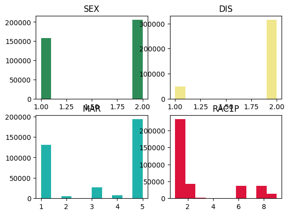

```python
i = 0
used = {}
a=0
b=0
fig,ax = plt.subplots(2,2)
plt.figure(figsize=(12,12))
for col in ['SEX','DIS','MAR','RAC1P']:
    ax[a,b].hist(features[col],color=colors[i])
    ax[a,b].set_title(col)
    used[col]=colors[i]
    i+=1
    b+=1
    if b==2:
        a=1
        b=0
plt.show()
```

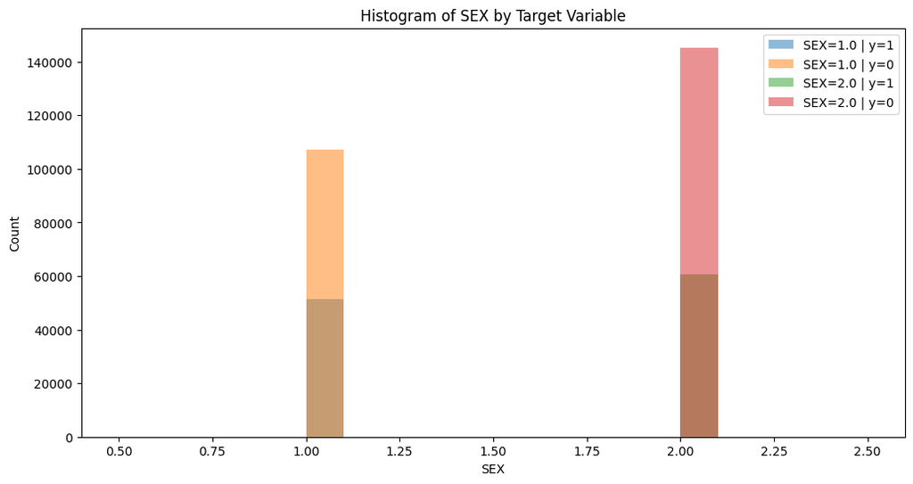

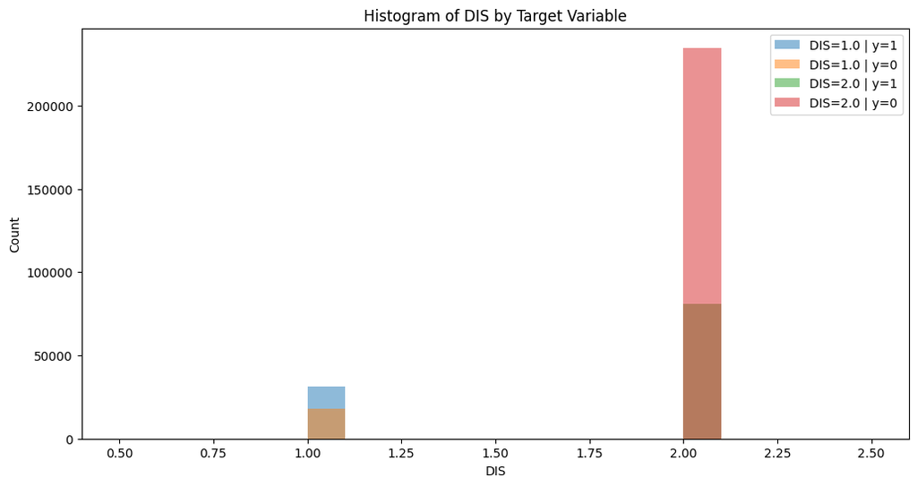

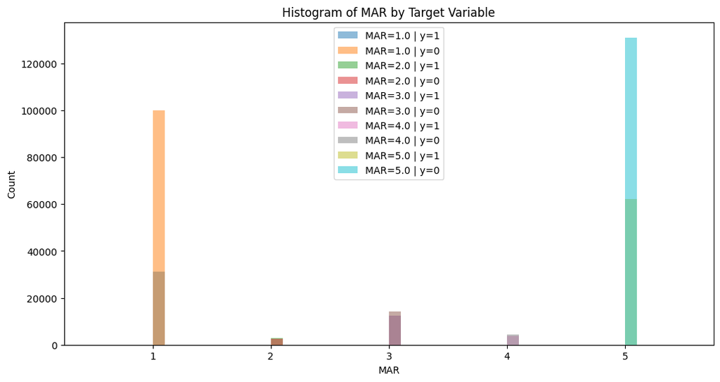

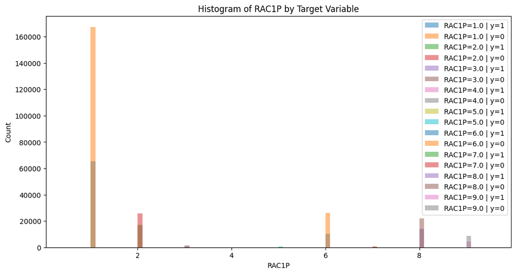

```python
sensitive_attributes = ['SEX', 'DIS', 'MAR', 'RAC1P']

data = features.clone()
data = data.with_columns(label = labels['PUBCOV']._recursive_cast_to_dtype(int))

def plot_histograms(data, sensitive_attributes, target_col='label'):

    for attr in sensitive_attributes:
        unique_groups = data[attr].unique()
        plt.figure(figsize=(12, 6))
        for group in unique_groups:
            plt.hist(data.filter((pl.col(attr) == group) & (pl.col(target_col) == 1))[attr], alpha=0.5, label=f"{attr}={group} | y=1")
            plt.hist(data.filter((pl.col(attr) == group )& (pl.col(target_col) == 0))[attr], alpha=0.5, label=f"{attr}={group} | y=0")

        plt.title(f"Histogram of {attr} by Target Variable")
        plt.xlabel(attr)
        plt.ylabel("Count")
        plt.legend()
        plt.show()

plot_histograms(data, sensitive_attributes, target_col='label')
```

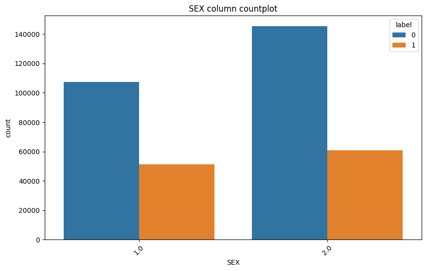

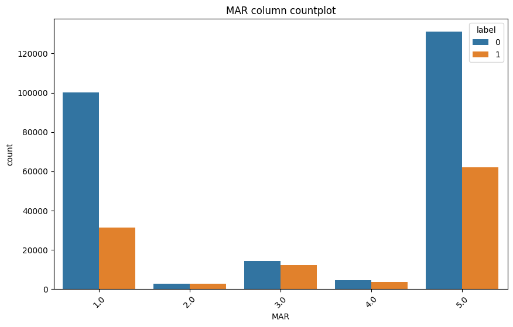

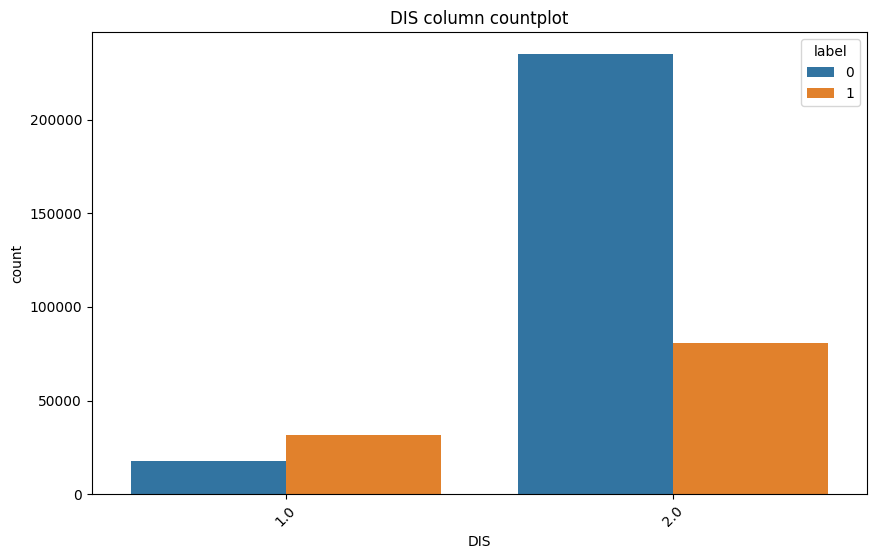

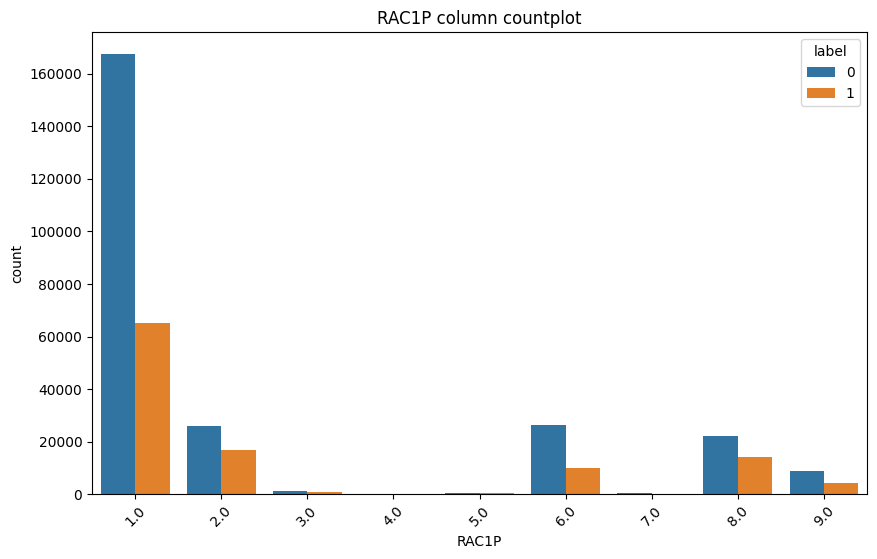

```python
plt.figure(figsize=(10,6))
sns.countplot(data=data,hue='label',x='SEX')
plt.title("SEX column countplot")
plt.xticks(rotation=45)
plt.show()

plt.figure(figsize=(10,6))
sns.countplot(data=data,hue='label',x='MAR')
plt.title("MAR column countplot")
plt.xticks(rotation=45)
plt.show()

plt.figure(figsize=(10,6))
sns.countplot(data=data,hue='label',x='DIS')
plt.title("DIS column countplot")
plt.xticks(rotation=45)
plt.show()

plt.figure(figsize=(10,6))
sns.countplot(data=data,hue='label',x='RAC1P')
plt.title("RAC1P column countplot")
plt.xticks(rotation=45)
plt.show()
```

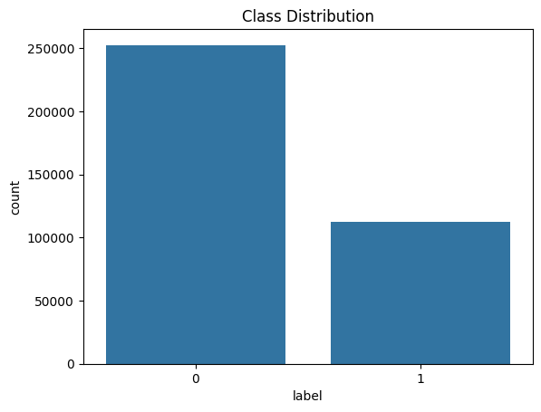

```python
sns.countplot(x='label', data=data)
plt.title("Class Distribution")
plt.show()
```

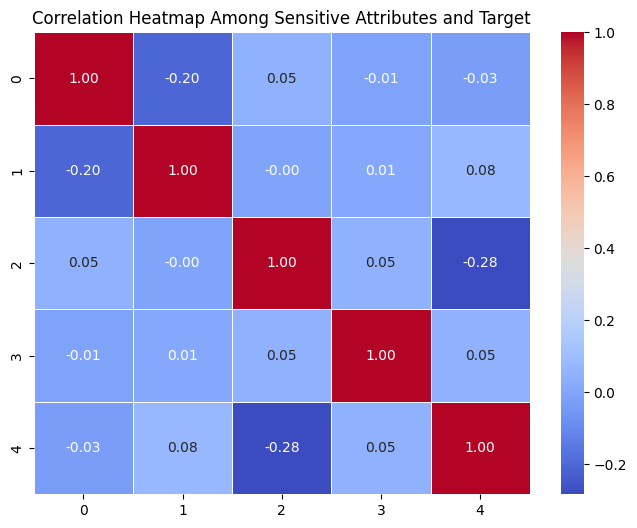

```python
correlation_matrix = data['SEX','MAR','DIS','RAC1P','label'].corr()

# Plot the heatmap
plt.figure(figsize=(8, 6))
sns.heatmap(correlation_matrix, annot=True, fmt=".2f", cmap="coolwarm", linewidths=0.5)
plt.title("Correlation Heatmap Among Sensitive Attributes and Target")
plt.show()
```

```python
print("\nSummary Statistics:")
print(data.describe())

numerical_cols = data.select(pl.selectors.numeric()).columns
numerical_cols.remove('label')
preprocessor = ColumnTransformer(
    transformers=[
        ('num', StandardScaler(), numerical_cols),
    ]
)

X = data.drop(['label'])
y = data['label']
X_train, X_test, y_train, y_test = train_test_split(X, y, test_size=0.2, random_state=42, stratify=y)
```

```
Summary Statistics:
shape: (9, 21)
┌────────────┬───────────┬───────────┬──────────┬───┬───────────┬──────────┬──────────┬──────────┐
│ statistic  ┆ AGEP      ┆ SCHL      ┆ MAR      ┆ … ┆ ST        ┆ FER      ┆ RAC1P    ┆ label    │
│ ---        ┆ ---       ┆ ---       ┆ ---      ┆   ┆ ---       ┆ ---      ┆ ---      ┆ ---      │
│ str        ┆ f64       ┆ f64       ┆ f64      ┆   ┆ f64       ┆ f64      ┆ f64      ┆ f64      │
╞════════════╪═══════════╪═══════════╪══════════╪═══╪═══════════╪══════════╪══════════╪══════════╡
│ count      ┆ 364726.0  ┆ 364726.0  ┆ 364726.0 ┆ … ┆ 364726.0  ┆ 364726.0 ┆ 364726.0 ┆ 364726.0 │
│ null_count ┆ 0.0       ┆ 0.0       ┆ 0.0      ┆ … ┆ 0.0       ┆ 0.0      ┆ 0.0      ┆ 0.0      │
│ mean       ┆ 35.933569 ┆ 16.554655 ┆ 3.346452 ┆ … ┆ 24.817581 ┆ 0.80549  ┆ 2.630556 ┆ 0.307538 │
│ std        ┆ 15.550484 ┆ 4.126389  ┆ 1.864167 ┆ … ┆ 17.82939  ┆ 0.970503 ┆ 2.692612 ┆ 0.461475 │
│ min        ┆ 15.0      ┆ 1.0       ┆ 1.0      ┆ … ┆ 6.0       ┆ 0.0      ┆ 1.0      ┆ 0.0      │
│ 25%        ┆ 21.0      ┆ 15.0      ┆ 1.0      ┆ … ┆ 6.0       ┆ 0.0      ┆ 1.0      ┆ 0.0      │
│ 50%        ┆ 33.0      ┆ 17.0      ┆ 5.0      ┆ … ┆ 25.0      ┆ 0.0      ┆ 1.0      ┆ 0.0      │
│ 75%        ┆ 50.0      ┆ 19.0      ┆ 5.0      ┆ … ┆ 48.0      ┆ 2.0      ┆ 2.0      ┆ 1.0      │
│ max        ┆ 64.0      ┆ 24.0      ┆ 5.0      ┆ … ┆ 48.0      ┆ 2.0      ┆ 9.0      ┆ 1.0      │
└────────────┴───────────┴───────────┴──────────┴───┴───────────┴──────────┴──────────┴──────────┘
```

```python
model_pipeline = Pipeline([
    ('preprocessor', preprocessor),
    ('classifier', LogisticRegression())
])

model_pipeline.fit(X_train, y_train)

y_pred = model_pipeline.predict(X_test)
print("Model Accuracy:", accuracy_score(y_test, y_pred))
print("Classification Report:\n", classification_report(y_test, y_pred))
```

```
Model Accuracy: 0.7396430236065035
Classification Report:
               precision    recall  f1-score   support

           0       0.75      0.93      0.83     50512
           1       0.67      0.31      0.42     22434

    accuracy                           0.74     72946
   macro avg       0.71      0.62      0.63     72946
weighted avg       0.73      0.74      0.71     72946
```

```python
model_pipeline = Pipeline([
    ('preprocessor', preprocessor),
    ('classifier', DecisionTreeClassifier())
])

model_pipeline.fit(X_train, y_train)

y_pred = model_pipeline.predict(X_test)
print("Model Accuracy:", accuracy_score(y_test, y_pred))
print("Classification Report:\n", classification_report(y_test, y_pred))
```

```
Model Accuracy: 0.7226715652674581
Classification Report:
               precision    recall  f1-score   support

           0       0.80      0.81      0.80     50512
           1       0.55      0.53      0.54     22434

    accuracy                           0.72     72946
   macro avg       0.67      0.67      0.67     72946
weighted avg       0.72      0.72      0.72     72946
```

```python
import numpy as np
from sklearn.metrics import confusion_matrix, accuracy_score

def compute_fairness_metrics(y_true, y_pred, sensitive_attr):
    unique_groups = np.unique(sensitive_attr)
    results = {}

    parity_values = {
        "Demographic Parity": [],
        "TPR": [],
        "FPR": [],
        "PPV": [],
        "NPV": [],
        "Disparate Mistreatment": [],
        "Equalized Odds": []
    }

    for group in unique_groups:
        idx = (sensitive_attr == group)
        y_true_g = y_true[idx]
        y_pred_g = y_pred[idx]
        tn, fp, fn, tp = confusion_matrix(y_true_g, y_pred_g).ravel()

        TPR = tp / (tp + fn) if (tp + fn) > 0 else 0  # True Positive Rate
        FPR = fp / (fp + tn) if (fp + tn) > 0 else 0  # False Positive Rate
        PPV = tp / (tp + fp) if (tp + fp) > 0 else 0  # Positive Predictive Value (Precision)
        NPV = tn / (tn + fn) if (tn + fn) > 0 else 0  # Negative Predictive Value
        Disparate_Mistreatment = abs((fp + fn) / len(y_true_g))  # Error Rate Disparity
        Equalized_Odds = abs(TPR - FPR)  # Equalized Odds Calculation
        Demographic_Parity = np.mean(y_pred_g)

        parity_values["Demographic Parity"].append(Demographic_Parity)
        parity_values["TPR"].append(TPR)
        parity_values["FPR"].append(FPR)
        parity_values["PPV"].append(PPV)
        parity_values["NPV"].append(NPV)
        parity_values["Disparate Mistreatment"].append(Disparate_Mistreatment)
        parity_values["Equalized Odds"].append(Equalized_Odds)

        results[group] = {
            "Demographic Parity": Demographic_Parity,
            "Accuracy": accuracy_score(y_true_g, y_pred_g),
            "TPR": TPR,
            "FPR": FPR,
            "PPV": PPV,
            "NPV": NPV,
            "Disparate Mistreatment": Disparate_Mistreatment,
            "Equalized Odds": Equalized_Odds
        }

    fairness_differences = {
        "Demographic Parity Difference": max(parity_values["Demographic Parity"]) - min(parity_values["Demographic Parity"]),
        "TPR Difference": max(parity_values["TPR"]) - min(parity_values["TPR"]),
        "FPR Difference": max(parity_values["FPR"]) - min(parity_values["FPR"]),
        "PPV Difference": max(parity_values["PPV"]) - min(parity_values["PPV"]),
        "NPV Difference": max(parity_values["NPV"]) - min(parity_values["NPV"]),
        "Disparate Mistreatment Difference": max(parity_values["Disparate Mistreatment"]) - min(parity_values["Disparate Mistreatment"]),
        "Equalized Odds Difference": max(parity_values["Equalized Odds"]) - min(parity_values["Equalized Odds"])
    }

    return results, fairness_differences

group_metrics, fairness_diffs = compute_fairness_metrics(y_test.to_pandas(), y_pred, X_test['DIS'])

print("Group-wise Fairness Metrics:")
for group, metrics in group_metrics.items():
    print(f"Group {group}: {metrics}")

print("\nFairness Differences Across Groups:")
for metric, diff in fairness_diffs.items():
    print(f"{metric}: {diff:.4f}")
```

```
Group-wise Fairness Metrics:
Group 1.0: {'Demographic Parity': np.float64(0.6372819100091828), 'Accuracy': 0.7314559738802163, 'TPR': np.float64(0.7881058673469388), 'FPR': np.float64(0.3692264097478039), 'PPV': np.float64(0.7913864873519052), 'NPV': np.float64(0.6261603375527426), 'Disparate Mistreatment': np.float64(0.2685440…
Group 2.0: {'Demographic Parity': np.float64(0.24356639480560616), 'Accuracy': 0.7213081004038324, 'TPR': np.float64(0.4313822546714515), 'FPR': np.float64(0.17895834663601728), 'PPV': np.float64(0.45331599479843954), 'NPV': np.float64(0.8075997068983566), 'Disparate Mistreatment': np.float64(0.2786…

Fairness Differences Across Groups:
Demographic Parity Difference: 0.3937
TPR Difference: 0.3567
FPR Difference: 0.1903
PPV Difference: 0.3381
NPV Difference: 0.1814
Disparate Mistreatment Difference: 0.0101
Equalized Odds Difference: 0.1665
```

```python
from lightgbm import LGBMClassifier
model_pipeline = Pipeline([
    ('preprocessor', preprocessor),
    ('classifier', LGBMClassifier())
])
model_pipeline.fit(X_train, y_train)

y_pred = model_pipeline.predict(X_test)
print("Model Accuracy:", accuracy_score(y_test, y_pred))
print("Classification Report:\n", classification_report(y_test, y_pred))
sensitive_features = ['DIS', 'SEX', 'MAR', 'RAC1P']
for s in sensitive_features:
    print(s)
    print(compute_fairness_metrics(y_test.to_pandas(),y_pred,X_test[s])[1])
    print()
```

[output not shown]

```
Model Accuracy: 0.7828119430811833
Classification Report:
               precision    recall  f1-score   support

           0       0.80      0.92      0.85     50512
           1       0.73      0.47      0.57     22434

    accuracy                           0.78     72946
   macro avg       0.76      0.70      0.71     72946
weighted avg       0.78      0.78      0.77     72946

DIS
{'Demographic Parity Difference': np.float64(0.5511852707100777), 'TPR Difference': np.float64(0.5507709607633426), 'FPR Difference': np.float64(0.276227776737487), 'PPV Difference': np.float64(0.17546691468066622), 'NPV Difference': np.float64(0.05949399047676218), 'Disparate Mistreatment Differenc…

SEX
{'Demographic Parity Difference': np.float64(0.03016837876639525), 'TPR Difference': np.float64(0.03359906855445993), 'FPR Difference': np.float64(0.01290543181695375), 'PPV Difference': np.float64(0.007808123967310343), 'NPV Difference': np.float64(0.012873445802533356), 'Disparate Mistreatment Dif…

MAR
{'Demographic Parity Difference': np.float64(0.4183275397558649), 'TPR Difference': np.float64(0.44672927461139894), 'FPR Difference': np.float64(0.22975841137166236), 'PPV Difference': np.float64(0.0800499030205587), 'NPV Difference': np.float64(0.09143950103686216), 'Disparate Mistreatment Differe…

RAC1P
{'Demographic Parity Difference': np.float64(0.19465585544974337), 'TPR Difference': np.float64(0.2950899313216446), 'FPR Difference': np.float64(0.19128970163618864), 'PPV Difference': np.float64(0.2857142857142857), 'NPV Difference': np.float64(0.24466019417475726), 'Disparate Mistreatment Differe…
```

```python
def perform_dataset_intervention(dataset):
    np.random.seed(23)

    numerical_cols = dataset.select(pl.selectors.numeric()).columns
    numerical_cols.remove('label')

    X = dataset.drop(['label'])
    y = dataset['label']

    X_train, X_test, y_train, y_test = train_test_split(X, y, test_size=0.2, random_state=42, stratify=y)
    rf_model = RandomForestClassifier(random_state=42)
    xgb_model = XGBClassifier(random_state=42, use_label_encoder=False, eval_metric='mlogloss')
    lgbm_model = LGBMClassifier(random_state=42)
    all_models = [LogisticRegression(),GaussianNB(),SVC(max_iter=1000),DecisionTreeClassifier(),rf_model,xgb_model,
                  lgbm_model,VotingClassifier(estimators=[
        ('Random Forest', rf_model),
        ('XGBoost', xgb_model),
        ('LightGBM', lgbm_model)
    ], voting='soft')]

    Model_Results = {}

    for model in all_models:
        preprocessor = ColumnTransformer(
            transformers=[
                ('num', StandardScaler(), numerical_cols),
            ]
        )
        model_pipeline = Pipeline([
            ('preprocessor', preprocessor),
            ('classifier', model)
        ])

        model_pipeline.fit(X_train, y_train)

        y_pred = model_pipeline.predict(X_test)
        group_metrics, fairness_diffs = compute_fairness_metrics(y_test.to_pandas(), y_pred, X_test['DIS'])
        report = classification_report(y_test.to_pandas(), y_pred)
        Model_Results[str(model)] = {'Classification Report':report,'Group Metrics':group_metrics,'Fairness':fairness_diffs}
        print("Model : ",str(model))
        print("Classification Report :",report)
        print("Fairness Differences :",fairness_diffs)
        print()
        print()
    return Model_Results
```

Baseline Models and Dataset Performance

```python
perform_dataset_intervention(data) # Baseline data - no modifications
```

```
Model :  LogisticRegression()
Classification Report :               precision    recall  f1-score   support

           0       0.75      0.93      0.83     50512
           1       0.67      0.31      0.42     22434

    accuracy                           0.74     72946
   macro avg       0.71      0.62      0.63     72946
weighted avg       0.73      0.74      0.71     72946

Fairness Differences : {'Demographic Parity Difference': np.float64(0.7816821612064404), 'TPR Difference': np.float64(0.8259097460912345), 'FPR Difference': np.float64(0.6469695811970407), 'PPV Difference': np.float64(0.1716104375379971), 'NPV Difference': np.float64(0.10158864576081783), 'Disparate…


Model :  GaussianNB()
Classification Report :               precision    recall  f1-score   support

           0       0.75      0.91      0.82     50512
           1       0.61      0.33      0.43     22434

    accuracy                           0.73     72946
   macro avg       0.68      0.62      0.62     72946
weighted avg       0.71      0.73      0.70     72946

Fairness Differences : {'Demographic Parity Difference': np.float64(0.9597080613529048), 'TPR Difference': np.float64(0.9341190140516051), 'FPR Difference': np.float64(0.962460252605672), 'PPV Difference': np.float64(0.16538960078986692), 'NPV Difference': np.float64(0.07260955991869189), 'Disparate…
```

```
Model :  SVC(max_iter=1000)
Classification Report :               precision    recall  f1-score   support

           0       0.69      0.95      0.80     50512
           1       0.28      0.04      0.07     22434

    accuracy                           0.67     72946
   macro avg       0.49      0.50      0.44     72946
weighted avg       0.56      0.67      0.58     72946

Fairness Differences : {'Demographic Parity Difference': np.float64(0.05402034333905904), 'TPR Difference': np.float64(0.05899165638597971), 'FPR Difference': np.float64(0.052246271987093695), 'PPV Difference': np.float64(0.22079439252336447), 'NPV Difference': np.float64(0.3853459577613171), 'Dispa…


Model :  DecisionTreeClassifier()
Classification Report :               precision    recall  f1-score   support

           0       0.80      0.81      0.80     50512
           1       0.55      0.53      0.54     22434

    accuracy                           0.72     72946
   macro avg       0.67      0.67      0.67     72946
weighted avg       0.72      0.72      0.72     72946

Fairness Differences : {'Demographic Parity Difference': np.float64(0.3942433183516117), 'TPR Difference': np.float64(0.35706867204250836), 'FPR Difference': np.float64(0.1910689231347897), 'PPV Difference': np.float64(0.3376328107850634), 'NPV Difference': np.float64(0.18146716799890783), 'Disparat…


Model :  RandomForestClassifier(random_state=42)
Classification Report :               precision    recall  f1-score   support

           0       0.81      0.88      0.84     50512
           1       0.66      0.52      0.58     22434

    accuracy                           0.77     72946
   macro avg       0.74      0.70      0.71     72946
weighted avg       0.76      0.77      0.76     72946

Fairness Differences : {'Demographic Parity Difference': np.float64(0.4917042785124185), 'TPR Difference': np.float64(0.47387425688627144), 'FPR Difference': np.float64(0.21706287872089075), 'PPV Difference': np.float64(0.25936703395396044), 'NPV Difference': np.float64(0.07420439065953466), 'Dispar…
```

```
Model :  XGBClassifier(base_score=None, booster=None, callbacks=None,
              colsample_bylevel=None, colsample_bynode=None,
              colsample_bytree=None, device=None, early_stopping_rounds=None,
              enable_categorical=False, eval_metric='mlogloss',
              feature_types=None, gamma=None, grow_policy=None,
              importance_type=None, interaction_constraints=None,
              learning_rate=None, max_bin=None, max_cat_threshold=None,
              max_cat_to_onehot=None, max_delta_step=None, max_depth=None,
              max_leaves=None, min_child_weight=None, missing=nan,
              monotone_constraints=None, multi_strategy=None, n_estimators=None,
              n_jobs=None, num_parallel_tree=None, random_state=42, ...)
Classification Report :               precision    recall  f1-score   support

           0       0.80      0.92      0.86     50512
           1       0.72      0.49      0.59     22434

    accuracy                           0.79     72946
   macro avg       0.76      0.70      0.72     72946
weighted avg       0.78      0.79      0.77     72946

Fairness Differences : {'Demographic Parity Difference': np.float64(0.5355714048870973), 'TPR Difference': np.float64(0.5213096503451028), 'FPR Difference': np.float64(0.26056986409178934), 'PPV Difference': np.float64(0.18146337399947643), 'NPV Difference': np.float64(0.06309184464044282), 'Dispara…


[LightGBM] [Info] Number of positive: 89733, number of negative: 202047
[LightGBM] [Info] Auto-choosing row-wise multi-threading, the overhead of testing was 0.030177 seconds.
You can set `force_row_wise=true` to remove the overhead.
And if memory is not enough, you can set `force_col_wise=true`.
[LightGBM] [Info] Total Bins 414
[LightGBM] [Info] Number of data points in the train set: 291780, number of used features: 19
[LightGBM] [Info] [binary:BoostFromScore]: pavg=0.307537 -> initscore=-0.811662
[LightGBM] [Info] Start training from score -0.811662
```

```
Model :  LGBMClassifier(random_state=42)
Classification Report :               precision    recall  f1-score   support

           0       0.80      0.92      0.85     50512
           1       0.72      0.47      0.57     22434

    accuracy                           0.78     72946
   macro avg       0.76      0.70      0.71     72946
weighted avg       0.77      0.78      0.77     72946

Fairness Differences : {'Demographic Parity Difference': np.float64(0.5537573110715254), 'TPR Difference': np.float64(0.5519799016779092), 'FPR Difference': np.float64(0.28341835802772863), 'PPV Difference': np.float64(0.17337821292217614), 'NPV Difference': np.float64(0.06248104713546143), 'Dispara…
```

[output not shown]

```
Model :  VotingClassifier(estimators=[('Random Forest',
                              RandomForestClassifier(random_state=42)),
                             ('XGBoost',
                              XGBClassifier(base_score=None, booster=None,
                                            callbacks=None,
                                            colsample_bylevel=None,
                                            colsample_bynode=None,
                                            colsample_bytree=None, device=None,
                                            early_stopping_rounds=None,
                                            enable_categorical=False,
                                            eval_metric='mlogloss',
                                            feature_types=None, gamma=None,
                                            grow_policy...
                                            interaction_constraints=None,
                                            learning_rate=None, max_bin=None,
                                            max_cat_threshold=None,
                                            max_cat_to_onehot=None,
                                            max_delta_step=None, max_depth=None,
                                            max_leaves=None,
                                            min_child_weight=None, missing=nan,
                                            monotone_constraints=None,
                                            multi_strategy=None,
                                            n_estimators=None, n_jobs=None,
                                            num_parallel_tree=None,
                                            random_state=42, ...)),
                             ('LightGBM', LGBMClassifier(random_state=42))],
                 voting='soft')
Classification Report :               precision    recall  f1-score   support

           0       0.80      0.92      0.86     50512
           1       0.73      0.50      0.59     22434

    accuracy                           0.79     72946
   macro avg       0.77      0.71      0.72     72946
weighted avg       0.78      0.79      0.78     72946

Fairness Differences : {'Demographic Parity Difference': np.float64(0.5362066821084905), 'TPR Difference': np.float64(0.5273111460429983), 'FPR Difference': np.float64(0.247183665372245), 'PPV Difference': np.float64(0.18139144724575262), 'NPV Difference': np.float64(0.047543985302049174), 'Disparat…
```

[output not shown]

[output cut: 137 more lines]

```
   np.float64(2.0): {'Demographic Parity': np.float64(0.1373980521023042),
    'Accuracy': 0.7858579459973077,
    'TPR': np.float64(0.35008043558965474),
    'FPR': np.float64(0.06423600025541153),
    'PPV': np.float64(0.6521438450899032),
    'NPV': np.float64(0.8071563641704456),
    'Disparate Mistreatment': np.float64(0.2141420540026922),
    'Equalized Odds': np.float64(0.2858444353342432)}},
  'Fairness': {'Demographic Parity Difference': np.float64(0.5362066821084905),
   'TPR Difference': np.float64(0.5273111460429983),
   'FPR Difference': np.float64(0.247183665372245),
   'PPV Difference': np.float64(0.18139144724575262),
   'NPV Difference': np.float64(0.047543985302049174),
   'Disparate Mistreatment Difference': np.float64(0.023549257349289504),
   'Equalized Odds Difference': np.float64(0.2801274806707533)}}}
```

Massaging

```python
import pandas as pd

import numpy as np
import pandas as pd
import math
from sklearn.linear_model import LogisticRegression

def compute_discrimination_score(df, label_col, sensitive_features):
    """Compute discrimination score as the disparity in positive class rates across sensitive groups."""
    discrimination = {}

    for feature in sensitive_features:
        pos_rates = {val: df[df[feature] == val][label_col].mean() for val in df[feature].unique()}
        max_rate = max(pos_rates.values())
        min_rate = min(pos_rates.values())

        discrimination[feature] = max_rate - min_rate  # Difference in Positive Rate (DPR)

    return discrimination

def find_relabel_candidates(df, label_col, sensitive_features, model):
    """Identify relabeling candidates based on logistic regression decision scores."""
    decision_scores = model.decision_function(df.drop(columns=[label_col] + sensitive_features))

    promote_candidates = {feat: [] for feat in sensitive_features}
    demote_candidates = {feat: [] for feat in sensitive_features}

    for feature in sensitive_features:
        for val in df[feature].unique():
            group_df = df[df[feature] == val]

            # Get decision scores for each group
            scores = decision_scores[group_df.index]

            # Candidates: Promote (y=0 → y=1) and Demote (y=1 → y=0)
            promote = [(s, i) for s, i in zip(scores, group_df.index) if df.loc[i, label_col] == 0]
            demote = [(s, i) for s, i in zip(scores, group_df.index) if df.loc[i, label_col] == 1]

            promote_candidates[feature].extend(promote)
            demote_candidates[feature].extend(demote)

        # Sort candidates by decision scores
        promote_candidates[feature].sort(reverse=True, key=lambda x: x[0])  # Highest scores first
        demote_candidates[feature].sort(key=lambda x: x[0])  # Lowest scores first

    return promote_candidates, demote_candidates

def apply_massaging(df, label_col, sensitive_features):
    """Apply massaging based on computed M values for each sensitive feature."""
    df_copy = df.copy()

    # Train logistic regression model
    model = LogisticRegression(C=1, solver='lbfgs')
    model.fit(df.drop(columns=[label_col] + sensitive_features), df[label_col])

    # Compute discrimination scores
    discrimination = compute_discrimination_score(df, label_col, sensitive_features)

    # Find relabeling candidates
    promote_candidates, demote_candidates = find_relabel_candidates(df, label_col, sensitive_features, model)

    # Apply relabeling for each sensitive feature
    for feature in sensitive_features:
        feature_values = df[feature].unique()
        total_samples = len(df)

        # Compute M dynamically for fair relabeling
        d_feature_counts = {val: len(df[df[feature] == val]) for val in feature_values}
        max_group = max(d_feature_counts, key=lambda x: df[df[feature] == x][label_col].mean())
        min_group = min(d_feature_counts, key=lambda x: df[df[feature] == x][label_col].mean())

        d_max = d_feature_counts[max_group]
        d_min = d_feature_counts[min_group]

        M = int(discrimination[feature] * d_max * d_min / total_samples)
        print(M)

        for i in range(math.ceil(2*M)):  # Apply equal relabeling to balance the dataset
            if i < len(promote_candidates[feature]):
                df_copy.loc[promote_candidates[feature][i][1], label_col] = 1
            if i < len(demote_candidates[feature]):
                df_copy.loc[demote_candidates[feature][i][1], label_col] = 0

    return df_copy

df_train = pd.DataFrame(X_train, columns= X_train.columns)
df_train['label'] = y_train  # Add label column

sensitive_features = ['DIS', 'SEX', 'MAR', 'RAC1P']
label_col = 'label'

# Apply Massaging
df_train_massaged = apply_massaging(df_train, label_col, sensitive_features)

# Extract transformed dataset
X_massaged = df_train_massaged.drop(columns=[label_col])
y_massaged = df_train_massaged[label_col]


def count_sensitive_feature_pairs(X_train, y_train, sensitive_features):
    """Counts the number of occurrences for each (zᵢ, yᵢ) pair in X_train."""
    df = pd.DataFrame(X_train, columns=X_train.columns)
    df['label'] = y_train  # Add label column

    results = {}

    for feature in sensitive_features:
        counts = df.groupby([feature, 'label']).size().unstack(fill_value=0)
        results[feature] = counts

    return results

sensitive_features = ['DIS', 'SEX', 'MAR', 'RAC1P']

print("-----------Before Massaging--------------")
feature_counts = count_sensitive_feature_pairs(X, y, sensitive_features)
for feature, counts in feature_counts.items():
    print(f"Feature: {feature}")
    print(counts)
    print("\n")
print("---------------------------------------")
print("-----------After Massaging--------------")
feature_counts = count_sensitive_feature_pairs(X_massaged, y_massaged, sensitive_features)
for feature, counts in feature_counts.items():
    print(f"Feature: {feature}")
    print(counts)
    print("\n")
```

```
13040
2076
440
0
-----------Before Massaging--------------
Feature: DIS
label       0      1
DIS
1.0     17732  31412
2.0    234827  80755


Feature: SEX
label       0      1
SEX
1.0    107252  51347
2.0    145307  60820


Feature: MAR
label       0      1
MAR
1.0    100017  31221
2.0      2714   2879
3.0     14290  12309
4.0      4473   3690
5.0    131065  62068


Feature: RAC1P
label       0      1
RAC1P
1.0    167374  65294
2.0     25887  16897
3.0      1240    815
4.0        17     14
5.0       541    345
6.0     26166  10078
7.0       485    205
8.0     22048  14081
```

[output cut: 26 more lines]

```
5.0    110704  43750


Feature: RAC1P
label       0      1
RAC1P
1.0    132653  53480
2.0     21855  12386
3.0       906    755
4.0         9     15
5.0       417    289
6.0     21386   7607
7.0       360    199
8.0     17305  11521
9.0      7156   3481
```

```python
X_massaged = data.drop(['label'])
y_massaged = data['label']
X_train_massaged, X_test_massaged, y_train_massaged, y_test_massaged = train_test_split(X_massaged, y_massaged, test_size=0.2, random_state=42, stratify=y_massaged)
model_pipeline = Pipeline([
    ('preprocessor', preprocessor),
    ('classifier', LogisticRegression())
])

model_pipeline.fit(X_train_massaged, y_train_massaged)

y_pred_massaged = model_pipeline.predict(X_test_massaged)
print("Model Accuracy:", accuracy_score(y_test_massaged, y_pred_massaged))
print("Classification Report:\n", classification_report(y_test_massaged, y_pred_massaged))
sensitive_features = ['DIS', 'SEX', 'MAR', 'RAC1P']
for s in sensitive_features:
    print(s)
    print(compute_fairness_metrics(y_test_massaged.to_pandas(),y_pred_massaged,X_test_massaged[s])[1])
    print("----------------------------")
```

```
Model Accuracy: 0.7396430236065035
Classification Report:
               precision    recall  f1-score   support

           0       0.75      0.93      0.83     50512
           1       0.67      0.31      0.42     22434

    accuracy                           0.74     72946
   macro avg       0.71      0.62      0.63     72946
weighted avg       0.73      0.74      0.71     72946

DIS
{'Demographic Parity Difference': np.float64(0.7816821612064404), 'TPR Difference': np.float64(0.8259097460912345), 'FPR Difference': np.float64(0.6469695811970407), 'PPV Difference': np.float64(0.1716104375379971), 'NPV Difference': np.float64(0.10158864576081783), 'Disparate Mistreatment Differenc…
----------------------------
SEX
{'Demographic Parity Difference': np.float64(0.044701129067877515), 'TPR Difference': np.float64(0.08302780106077762), 'FPR Difference': np.float64(0.01793335090651523), 'PPV Difference': np.float64(0.030693364102282406), 'NPV Difference': np.float64(0.0052526162964726675), 'Disparate Mistreatment D…
----------------------------
MAR
{'Demographic Parity Difference': np.float64(0.22903298298306257), 'TPR Difference': np.float64(0.273512988376978), 'FPR Difference': np.float64(0.12463441849406762), 'PPV Difference': np.float64(0.21906994983965355), 'NPV Difference': np.float64(0.19642775779950905), 'Disparate Mistreatment Differe…
----------------------------
RAC1P
{'Demographic Parity Difference': np.float64(0.3318951080639123), 'TPR Difference': np.float64(0.22066352652058158), 'FPR Difference': np.float64(0.44436958614051975), 'PPV Difference': np.float64(0.4166666666666667), 'NPV Difference': np.float64(0.2981651376146789), 'Disparate Mistreatment Differen…
----------------------------
```

```python
model_pipeline = Pipeline([
    ('preprocessor', preprocessor),
    ('classifier', DecisionTreeClassifier())
])

model_pipeline.fit(X_train, y_train)

y_pred = model_pipeline.predict(X_test)
print("Model Accuracy:", accuracy_score(y_test, y_pred))
print("Classification Report:\n", classification_report(y_test, y_pred))
sensitive_features = ['DIS', 'SEX', 'MAR', 'RAC1P']
for s in sensitive_features:
    print(s)
    print(compute_fairness_metrics(y_test.to_pandas(),y_pred,X_test[s]))
    print("----------------------------")
```

```
Model Accuracy: 0.7225344775587421
Classification Report:
               precision    recall  f1-score   support

           0       0.79      0.81      0.80     50512
           1       0.55      0.53      0.54     22434

    accuracy                           0.72     72946
   macro avg       0.67      0.67      0.67     72946
weighted avg       0.72      0.72      0.72     72946

DIS
({np.float64(1.0): {'Demographic Parity': np.float64(0.6360575451484543), 'Accuracy': 0.7314559738802163, 'TPR': np.float64(0.7871492346938775), 'FPR': np.float64(0.36752621139132896), 'PPV': np.float64(0.7919473853063843), 'NPV': np.float64(0.6257359125315392), 'Disparate Mistreatment': np.float64(…
----------------------------
SEX
({np.float64(1.0): {'Demographic Parity': np.float64(0.3093055381137762), 'Accuracy': 0.7258884842396082, 'TPR': np.float64(0.5544650665630162), 'FPR': np.float64(0.1922916376791429), 'PPV': np.float64(0.5791717417783191), 'NPV': np.float64(0.7915909090909091), 'Disparate Mistreatment': np.float64(0…
----------------------------
MAR
({np.float64(1.0): {'Demographic Parity': np.float64(0.2356490852843448), 'Accuracy': 0.7289844555627697, 'TPR': np.float64(0.42503238341968913), 'FPR': np.float64(0.17718798420552806), 'PPV': np.float64(0.42544570502431117), 'NPV': np.float64(0.822565332533853), 'Disparate Mistreatment': np.float64…
----------------------------
RAC1P
({np.float64(1.0): {'Demographic Parity': np.float64(0.26771247448157304), 'Accuracy': 0.7414849038358226, 'TPR': np.float64(0.5164236377590177), 'FPR': np.float64(0.17098940456648262), 'PPV': np.float64(0.5401348531064376), 'NPV': np.float64(0.8150952255186783), 'Disparate Mistreatment': np.float64…
----------------------------
```

```python
X_massaged = data.drop(['label'])
y_massaged = data['label']
X_train_massaged, X_test_massaged, y_train_massaged, y_test_massaged = train_test_split(X_massaged, y_massaged, test_size=0.2, random_state=42, stratify=y_massaged)
model_pipeline = Pipeline([
    ('preprocessor', preprocessor),
    ('classifier', XGBClassifier())
])

model_pipeline.fit(X_train_massaged, y_train_massaged)

y_pred_massaged = model_pipeline.predict(X_test_massaged)
print("Model Accuracy:", accuracy_score(y_test_massaged, y_pred_massaged))
print("Classification Report:\n", classification_report(y_test_massaged, y_pred_massaged))
sensitive_features = ['DIS', 'SEX', 'MAR', 'RAC1P']
for s in sensitive_features:
    print(s)
    print(compute_fairness_metrics(y_test_massaged.to_pandas(),y_pred_massaged,X_test_massaged[s]))
    print("----------------------------")
```

```
Model Accuracy: 0.7858278726729362
Classification Report:
               precision    recall  f1-score   support

           0       0.80      0.92      0.86     50512
           1       0.72      0.49      0.59     22434

    accuracy                           0.79     72946
   macro avg       0.76      0.70      0.72     72946
weighted avg       0.78      0.79      0.77     72946

DIS
({np.float64(1.0): {'Demographic Parity': np.float64(0.6738087950209163), 'Accuracy': 0.7985919804101622, 'TPR': np.float64(0.8691007653061225), 'FPR': np.float64(0.32672145083593085), 'PPV': np.float64(0.8254088431253785), 'NPV': np.float64(0.7431967469502658), 'Disparate Mistreatment': np.float64(…
----------------------------
SEX
({np.float64(1.0): {'Demographic Parity': np.float64(0.22661057390430742), 'Accuracy': 0.7816463644355143, 'TPR': np.float64(0.512778155670003), 'FPR': np.float64(0.09002365381939613), 'PPV': np.float64(0.7310889443059019), 'NPV': np.float64(0.7964601769911505), 'Disparate Mistreatment': np.float64(…
----------------------------
MAR
({np.float64(1.0): {'Demographic Parity': np.float64(0.11866478249245693), 'Accuracy': 0.8027345987854715, 'TPR': np.float64(0.3333873056994819), 'FPR': np.float64(0.05238166641675414), 'PPV': np.float64(0.6626971355004828), 'NPV': np.float64(0.8215895302478766), 'Disparate Mistreatment': np.float64…
----------------------------
RAC1P
({np.float64(1.0): {'Demographic Parity': np.float64(0.18375416353282475), 'Accuracy': 0.805458257225744, 'TPR': np.float64(0.4807367613200307), 'FPR': np.float64(0.06825846888524101), 'PPV': np.float64(0.732545901064203), 'NPV': np.float64(0.8218723673125526), 'Disparate Mistreatment': np.float64(0…
----------------------------
```

Re-Sampling

```python
  # Check column types


categorical_cols = ["MAR", "SEX", "RAC1P", "DIS"]


def manual_oversample(df, categorical_cols):
    for col in categorical_cols:
        category_counts = df[col].value_counts()
        print(category_counts)
        max_count = category_counts["count"].max()
        oversampled_rows = []
        for category, count in zip(category_counts[col], category_counts["count"]):
            if count < max_count:
                subset = df.filter(pl.col(col) == category)
                num_duplicates = max_count - count
                oversampled_rows.append(subset.sample(num_duplicates, with_replacement=True))
        if oversampled_rows:
            df = df.vstack(pl.concat(oversampled_rows))

    return df
data_balanced = manual_oversample(data, categorical_cols)
```

```
shape: (5, 2)
┌─────┬────────┐
│ MAR ┆ count  │
│ --- ┆ ---    │
│ f64 ┆ u32    │
╞═════╪════════╡
│ 2.0 ┆ 5593   │
│ 4.0 ┆ 8163   │
│ 5.0 ┆ 193133 │
│ 3.0 ┆ 26599  │
│ 1.0 ┆ 131238 │
└─────┴────────┘
shape: (2, 2)
┌─────┬────────┐
│ SEX ┆ count  │
│ --- ┆ ---    │
│ f64 ┆ u32    │
╞═════╪════════╡
│ 2.0 ┆ 611209 │
│ 1.0 ┆ 354456 │
└─────┴────────┘
shape: (9, 2)
┌───────┬────────┐
│ RAC1P ┆ count  │
│ ---   ┆ ---    │
│ f64   ┆ u32    │
╞═══════╪════════╡
│ 7.0   ┆ 2257   │
│ 4.0   ┆ 75     │
│ 6.0   ┆ 95293  │
│ 9.0   ┆ 38304  │
│ 8.0   ┆ 120365 │
│ 1.0   ┆ 780793 │
│ 2.0   ┆ 173456 │
│ 5.0   ┆ 3016   │
│ 3.0   ┆ 8859   │
└───────┴────────┘
shape: (2, 2)
┌─────┬─────────┐
│ DIS ┆ count   │
│ --- ┆ ---     │
│ f64 ┆ u32     │
╞═════╪═════════╡
│ 1.0 ┆ 1661937 │
│ 2.0 ┆ 5365200 │
└─────┴─────────┘
```

```python
perform_dataset_intervention(data_balanced)
```

```
Model :  LogisticRegression()
Classification Report :               precision    recall  f1-score   support

           0       0.70      0.67      0.68    975226
           1       0.73      0.76      0.75   1170854

    accuracy                           0.72   2146080
   macro avg       0.72      0.71      0.71   2146080
weighted avg       0.72      0.72      0.72   2146080

Fairness Differences : {'Demographic Parity Difference': np.float64(0.7050441974845043), 'TPR Difference': np.float64(0.6270342745098727), 'FPR Difference': np.float64(0.6458804089532537), 'PPV Difference': np.float64(0.2049406510436539), 'NPV Difference': np.float64(0.0038656133669079384), 'Dispara…


Model :  GaussianNB()
Classification Report :               precision    recall  f1-score   support

           0       0.68      0.71      0.69    975226
           1       0.75      0.72      0.73   1170854

    accuracy                           0.71   2146080
   macro avg       0.71      0.71      0.71   2146080
weighted avg       0.71      0.71      0.71   2146080

Fairness Differences : {'Demographic Parity Difference': np.float64(0.787977596834869), 'TPR Difference': np.float64(0.7137860434127528), 'FPR Difference': np.float64(0.7553596679352925), 'PPV Difference': np.float64(0.1037225863301392), 'NPV Difference': np.float64(0.1209578737478092), 'Disparate M…
```

```
Model :  SVC(max_iter=1000)
Classification Report :               precision    recall  f1-score   support

           0       0.45      0.00      0.01    975226
           1       0.55      1.00      0.71   1170854

    accuracy                           0.55   2146080
   macro avg       0.50      0.50      0.36   2146080
weighted avg       0.50      0.55      0.39   2146080

Fairness Differences : {'Demographic Parity Difference': np.float64(0.004528410321257725), 'TPR Difference': np.float64(0.006197960816381576), 'FPR Difference': np.float64(0.004128881029410891), 'PPV Difference': np.float64(0.37600111328448066), 'NPV Difference': np.float64(0.4089088490612384), 'Dis…


Model :  DecisionTreeClassifier()
Classification Report :               precision    recall  f1-score   support

           0       0.99      0.99      0.99    975226
           1       0.99      0.99      0.99   1170854

    accuracy                           0.99   2146080
   macro avg       0.99      0.99      0.99   2146080
weighted avg       0.99      0.99      0.99   2146080

Fairness Differences : {'Demographic Parity Difference': np.float64(0.3783776100358631), 'TPR Difference': np.float64(0.025399237776218886), 'FPR Difference': np.float64(0.008878770050863008), 'PPV Difference': np.float64(0.01731690862280133), 'NPV Difference': np.float64(0.01305982918159021), 'Disp…


Model :  RandomForestClassifier(random_state=42)
Classification Report :               precision    recall  f1-score   support

           0       0.99      0.99      0.99    975226
           1       1.00      0.99      0.99   1170854

    accuracy                           0.99   2146080
   macro avg       0.99      0.99      0.99   2146080
weighted avg       0.99      0.99      0.99   2146080

Fairness Differences : {'Demographic Parity Difference': np.float64(0.37969495776024254), 'TPR Difference': np.float64(0.025633621311164423), 'FPR Difference': np.float64(0.006981395000640407), 'PPV Difference': np.float64(0.013958293177183445), 'NPV Difference': np.float64(0.013286582576225725), 'D…
```

```
Model :  XGBClassifier(base_score=None, booster=None, callbacks=None,
              colsample_bylevel=None, colsample_bynode=None,
              colsample_bytree=None, device=None, early_stopping_rounds=None,
              enable_categorical=False, eval_metric='mlogloss',
              feature_types=None, gamma=None, grow_policy=None,
              importance_type=None, interaction_constraints=None,
              learning_rate=None, max_bin=None, max_cat_threshold=None,
              max_cat_to_onehot=None, max_delta_step=None, max_depth=None,
              max_leaves=None, min_child_weight=None, missing=nan,
              monotone_constraints=None, multi_strategy=None, n_estimators=None,
              n_jobs=None, num_parallel_tree=None, random_state=42, ...)
Classification Report :               precision    recall  f1-score   support

           0       0.87      0.91      0.89    975226
           1       0.92      0.89      0.91   1170854

    accuracy                           0.90   2146080
   macro avg       0.90      0.90      0.90   2146080
weighted avg       0.90      0.90      0.90   2146080

Fairness Differences : {'Demographic Parity Difference': np.float64(0.438861560556346), 'TPR Difference': np.float64(0.2556922265220887), 'FPR Difference': np.float64(0.04055198328089166), 'PPV Difference': np.float64(0.12114069508574576), 'NPV Difference': np.float64(0.07203868985109374), 'Disparat…


[LightGBM] [Info] Number of positive: 4683414, number of negative: 3900906
[LightGBM] [Info] Auto-choosing row-wise multi-threading, the overhead of testing was 0.284279 seconds.
You can set `force_row_wise=true` to remove the overhead.
And if memory is not enough, you can set `force_col_wise=true`.
[LightGBM] [Info] Total Bins 411
[LightGBM] [Info] Number of data points in the train set: 8584320, number of used features: 19
[LightGBM] [Info] [binary:BoostFromScore]: pavg=0.545578 -> initscore=0.182818
[LightGBM] [Info] Start training from score 0.182818
```

```
Model :  LGBMClassifier(random_state=42)
Classification Report :               precision    recall  f1-score   support

           0       0.83      0.88      0.85    975226
           1       0.89      0.85      0.87   1170854

    accuracy                           0.86   2146080
   macro avg       0.86      0.86      0.86   2146080
weighted avg       0.86      0.86      0.86   2146080

Fairness Differences : {'Demographic Parity Difference': np.float64(0.49240594902504586), 'TPR Difference': np.float64(0.35153562593371435), 'FPR Difference': np.float64(0.13880779016003159), 'PPV Difference': np.float64(0.11981901769185299), 'NPV Difference': np.float64(0.0716150722046176), 'Dispar…
```

[output not shown]

```
Model :  VotingClassifier(estimators=[('Random Forest',
                              RandomForestClassifier(random_state=42)),
                             ('XGBoost',
                              XGBClassifier(base_score=None, booster=None,
                                            callbacks=None,
                                            colsample_bylevel=None,
                                            colsample_bynode=None,
                                            colsample_bytree=None, device=None,
                                            early_stopping_rounds=None,
                                            enable_categorical=False,
                                            eval_metric='mlogloss',
                                            feature_types=None, gamma=None,
                                            grow_policy...
                                            interaction_constraints=None,
                                            learning_rate=None, max_bin=None,
                                            max_cat_threshold=None,
                                            max_cat_to_onehot=None,
                                            max_delta_step=None, max_depth=None,
                                            max_leaves=None,
                                            min_child_weight=None, missing=nan,
                                            monotone_constraints=None,
                                            multi_strategy=None,
                                            n_estimators=None, n_jobs=None,
                                            num_parallel_tree=None,
                                            random_state=42, ...)),
                             ('LightGBM', LGBMClassifier(random_state=42))],
                 voting='soft')
Classification Report :               precision    recall  f1-score   support

           0       0.95      0.98      0.96    975226
           1       0.98      0.96      0.97   1170854

    accuracy                           0.97   2146080
   macro avg       0.97      0.97      0.97   2146080
weighted avg       0.97      0.97      0.97   2146080

Fairness Differences : {'Demographic Parity Difference': np.float64(0.4167954807280038), 'TPR Difference': np.float64(0.10873440218936103), 'FPR Difference': np.float64(0.0348449471229161), 'PPV Difference': np.float64(0.007769745686428853), 'NPV Difference': np.float64(0.04423269222408954), 'Dispar…
```

[output not shown]

[output cut: 137 more lines]

[output not shown]

Model Intervention

```python
import warnings
warnings.filterwarnings('ignore')
```

```python
from fairlearn.reductions import ExponentiatedGradient, DemographicParity
from sklearn.pipeline import make_pipeline

def perform_model_intervention(dataset, selected_models=None, use_fairness_constraints=True):
    np.random.seed(42)

    numerical_cols = dataset.select(pl.selectors.numeric()).columns
    numerical_cols.remove('label')

    X = dataset.drop(['label'])
    y = dataset['label']
    X_train, X_test, y_train, y_test = train_test_split(X, y, test_size=0.2, random_state=42, stratify=y)

    models_with_params = {
    LogisticRegression(): {
        'C': [0.01, 0.1, 1, 10],
        'penalty': ['l1', 'l2']
    },
    DecisionTreeClassifier(random_state=42): {
        'max_depth': [5, 10, 20, None],  # Controls tree depth
        'min_samples_split': [2, 5, 10],  # Minimum samples required to split
        'min_samples_leaf': [1, 2, 5],  # Minimum samples in leaf node
        'criterion': ['gini', 'entropy'],  # Splitting criteria
        'max_features': [None, 'sqrt', 'log2']  # Number of features considered at each split
    },
    # RandomForestClassifier(random_state=42): {
    #     'n_estimators': [50, 100, 200],
    #     'max_depth': [5, 10, 20]
    # },
    XGBClassifier(random_state=42, use_label_encoder=False, eval_metric='mlogloss'): {
        'n_estimators': [50, 100],
        'learning_rate': [0.01, 0.1]
    },
    # LGBMClassifier(random_state=42): {
    #     'n_estimators': [50, 100],
    #     'learning_rate': [0.01, 0.1]
    # }
}


    if selected_models is not None:
        models_with_params = {k: v for k, v in models_with_params.items() if type(k) in selected_models}

    Model_Results = {}

    for model, param_grid in models_with_params.items():
        preprocessor = ColumnTransformer([('num', StandardScaler(), numerical_cols)])

        if param_grid:
            if isinstance(model, (RandomForestClassifier, XGBClassifier, LGBMClassifier)):
                search = RandomizedSearchCV(model, param_grid, scoring='accuracy', cv=3, n_jobs=-1, n_iter=10)
            else:
                search = GridSearchCV(model, param_grid, scoring='accuracy', cv=3, n_jobs=-1)
            search.fit(X_train, y_train)
            best_model = search.best_estimator_
        else:
            best_model = model.fit(X_train, y_train)

        if use_fairness_constraints:
            if isinstance(best_model, (LogisticRegression, RandomForestClassifier, XGBClassifier, LGBMClassifier)):
                fair_model = ExponentiatedGradient(best_model, constraints=DemographicParity())
                fair_model.fit(X_train, y_train, sensitive_features=X_train['DIS'])
                y_pred = fair_model.predict(X_test)
            else:
                print(f"Skipping fairness constraints for {str(model)} (does not support sample_weight).")
                y_pred = best_model.predict(X_test)
        else:
            y_pred = best_model.predict(X_test)

        group_metrics, fairness_diffs = compute_fairness_metrics(y_test.to_pandas(), y_pred, X_test['DIS'])
        report = classification_report(y_test.to_pandas(), y_pred)

        Model_Results[str(model)] = {
            'Best Parameters': search.best_params_ if param_grid else "No tuning",
            'Classification Report': report,
            'Group Metrics': group_metrics,
            'Fairness': fairness_diffs
        }

        print(f"Model: {str(model)}")
        print("Best Parameters:", Model_Results[str(model)]['Best Parameters'])
        print("Classification Report:\n", report)
        print("Fairness Differences:", fairness_diffs)
        print("\n" + "-"*80 + "\n")

    return Model_Results

results = perform_model_intervention(data, selected_models=[LogisticRegression, DecisionTreeClassifier, XGBClassifier], use_fairness_constraints=False)
```

[output not shown]

[output cut: 41 more lines]

[output not shown]

```
Model: LogisticRegression()
Best Parameters: {'C': 1, 'penalty': 'l2'}
Classification Report:
               precision    recall  f1-score   support

           0       0.72      0.93      0.81     50512
           1       0.56      0.20      0.30     22434

    accuracy                           0.71     72946
   macro avg       0.64      0.57      0.56     72946
weighted avg       0.67      0.71      0.66     72946

Fairness Differences: {'Demographic Parity Difference': np.float64(0.17287367573457552), 'TPR Difference': np.float64(0.17831239235268417), 'FPR Difference': np.float64(0.06903546688993402), 'PPV Difference': np.float64(0.36848692045129605), 'NPV Difference': np.float64(0.34078220229733175), 'Dispar…

--------------------------------------------------------------------------------

Model: DecisionTreeClassifier(random_state=42)
Best Parameters: {'criterion': 'entropy', 'max_depth': 10, 'max_features': None, 'min_samples_leaf': 5, 'min_samples_split': 2}
Classification Report:
               precision    recall  f1-score   support

           0       0.79      0.91      0.85     50512
           1       0.69      0.45      0.54     22434

    accuracy                           0.77     72946
   macro avg       0.74      0.68      0.69     72946
weighted avg       0.76      0.77      0.75     72946

Fairness Differences: {'Demographic Parity Difference': np.float64(0.5480913653071529), 'TPR Difference': np.float64(0.5535226360838854), 'FPR Difference': np.float64(0.29867406445770917), 'PPV Difference': np.float64(0.20490175526908527), 'NPV Difference': np.float64(0.09511711314633253), 'Disparat…

--------------------------------------------------------------------------------
```

[output not shown]

```
Model: XGBClassifier(base_score=None, booster=None, callbacks=None,
              colsample_bylevel=None, colsample_bynode=None,
              colsample_bytree=None, device=None, early_stopping_rounds=None,
              enable_categorical=False, eval_metric='mlogloss',
              feature_types=None, gamma=None, grow_policy=None,
              importance_type=None, interaction_constraints=None,
              learning_rate=None, max_bin=None, max_cat_threshold=None,
              max_cat_to_onehot=None, max_delta_step=None, max_depth=None,
              max_leaves=None, min_child_weight=None, missing=nan,
              monotone_constraints=None, multi_strategy=None, n_estimators=None,
              n_jobs=None, num_parallel_tree=None, random_state=42, ...)
Best Parameters: {'n_estimators': 100, 'learning_rate': 0.1}
Classification Report:
               precision    recall  f1-score   support

           0       0.80      0.92      0.86     50512
           1       0.73      0.47      0.57     22434

    accuracy                           0.78     72946
   macro avg       0.76      0.70      0.71     72946
weighted avg       0.78      0.78      0.77     72946

Fairness Differences: {'Demographic Parity Difference': np.float64(0.5532271149069428), 'TPR Difference': np.float64(0.5583266935037844), 'FPR Difference': np.float64(0.27385951450205), 'PPV Difference': np.float64(0.17101282499553705), 'NPV Difference': np.float64(0.05763980713493877), 'Disparate M…

--------------------------------------------------------------------------------
```

### Research Paper Implementation - Fairness Constrained Optimization

```python
def custom_model_intervention(dataset, selected_models=None, use_fairness_constraints=True):
    np.random.seed(42)

    numerical_cols = dataset.select(pl.selectors.numeric()).columns
    numerical_cols.remove('label')

    X = dataset.drop(['label'])
    y = dataset['label']
    X_train, X_test, y_train, y_test = train_test_split(X, y, test_size=0.2, random_state=42, stratify=y)

    models = [
    LogisticRegression(),
    DecisionTreeClassifier(random_state=42),
    RandomForestClassifier(random_state=42),
    XGBClassifier(random_state=42, use_label_encoder=False, eval_metric='mlogloss'),
    LGBMClassifier(random_state=42)
    ]



    Model_Results = {}

    for model in models:
        if type(model) in selected_models:
            pass

        else: continue
        best_model = model.fit(X_train, y_train)

        if use_fairness_constraints:
            if isinstance(best_model, (LogisticRegression, RandomForestClassifier, XGBClassifier, LGBMClassifier)):
                fair_model = ExponentiatedGradient(best_model, constraints=DemographicParity())
                fair_model.fit(X_train, y_train, sensitive_features=X_train['DIS'])
                y_pred = fair_model.predict(X_test)
            else:
                print(f"Skipping fairness constraints for {str(model)} (does not support sample_weight).")
                y_pred = best_model.predict(X_test)
        else:
            y_pred = best_model.predict(X_test)

        group_metrics, fairness_diffs = compute_fairness_metrics(y_test.to_pandas(), y_pred, X_test['DIS'])
        report = classification_report(y_test.to_pandas(), y_pred)

        Model_Results[str(model)] = {
            'Classification Report': report,
            'Group Metrics': group_metrics,
            'Fairness': fairness_diffs
        }

        print(f"Model: {str(model)}")
        print("Classification Report:\n", report)
        print("Fairness Differences:", fairness_diffs)
        print("\n" + "-"*80 + "\n")

    return Model_Results

results = custom_model_intervention(data, selected_models=[LogisticRegression, DecisionTreeClassifier ,XGBClassifier], use_fairness_constraints=True)
```

```
Model: LogisticRegression()
Classification Report:
               precision    recall  f1-score   support

           0       0.70      0.97      0.82     50512
           1       0.53      0.07      0.13     22434

    accuracy                           0.69     72946
   macro avg       0.62      0.52      0.47     72946
weighted avg       0.65      0.69      0.60     72946

Fairness Differences: {'Demographic Parity Difference': np.float64(0.009982658385924562), 'TPR Difference': np.float64(0.007645682174614685), 'FPR Difference': np.float64(0.007269747526352163), 'PPV Difference': np.float64(0.3766128907757622), 'NPV Difference': np.float64(0.38206103727544494), 'Disp…

--------------------------------------------------------------------------------

Skipping fairness constraints for DecisionTreeClassifier(random_state=42) (does not support sample_weight).
Model: DecisionTreeClassifier(random_state=42)
Classification Report:
               precision    recall  f1-score   support

           0       0.80      0.81      0.80     50512
           1       0.55      0.53      0.54     22434

    accuracy                           0.72     72946
   macro avg       0.67      0.67      0.67     72946
weighted avg       0.72      0.72      0.72     72946

Fairness Differences: {'Demographic Parity Difference': np.float64(0.3926599089075064), 'TPR Difference': np.float64(0.3544938176978501), 'FPR Difference': np.float64(0.19033858656134026), 'PPV Difference': np.float64(0.33736520488856936), 'NPV Difference': np.float64(0.18303943356400554), 'Disparat…

--------------------------------------------------------------------------------

Model: XGBClassifier(base_score=None, booster=None, callbacks=None,
              colsample_bylevel=None, colsample_bynode=None,
              colsample_bytree=None, device=None, early_stopping_rounds=None,
              enable_categorical=False, eval_metric='mlogloss',
              feature_types=None, gamma=None, grow_policy=None,
              importance_type=None, interaction_constraints=None,
              learning_rate=None, max_bin=None, max_cat_threshold=None,
              max_cat_to_onehot=None, max_delta_step=None, max_depth=None,
              max_leaves=None, min_child_weight=None, missing=nan,
              monotone_constraints=None, multi_strategy=None, n_estimators=None,
              n_jobs=None, num_parallel_tree=None, random_state=42, ...)
Classification Report:
               precision    recall  f1-score   support

           0       0.78      0.90      0.83     50512
           1       0.64      0.42      0.51     22434

    accuracy                           0.75     72946
   macro avg       0.71      0.66      0.67     72946
weighted avg       0.73      0.75      0.73     72946

Fairness Differences: {'Demographic Parity Difference': np.float64(0.01568031606303308), 'TPR Difference': np.float64(0.1295343669580194), 'FPR Difference': np.float64(0.09238722069739061), 'PPV Difference': np.float64(0.3840153243204465), 'NPV Difference': np.float64(0.375778598365606), 'Disparate …

--------------------------------------------------------------------------------
```

Post-Model Processing

```python
model_pipeline = Pipeline([
    ('preprocessor', preprocessor),
    ('classifier', LogisticRegression())
])

model_pipeline.fit(X_train, y_train)
y_pred = model_pipeline.predict(X_test)

print("Model Accuracy:", accuracy_score(y_test, y_pred))
print("Classification Report:\n", classification_report(y_test, y_pred))
sensitive_features = ['DIS', 'SEX', 'MAR', 'RAC1P']
for s in sensitive_features:
    print(s)
    print(compute_fairness_metrics(y_test.to_pandas(),y_pred,X_test[s])[1])
    print("----------------------------")
```

```
Model Accuracy: 0.7396430236065035
Classification Report:
               precision    recall  f1-score   support

           0       0.75      0.93      0.83     50512
           1       0.67      0.31      0.42     22434

    accuracy                           0.74     72946
   macro avg       0.71      0.62      0.63     72946
weighted avg       0.73      0.74      0.71     72946

DIS
{'Demographic Parity Difference': np.float64(0.7816821612064404), 'TPR Difference': np.float64(0.8259097460912345), 'FPR Difference': np.float64(0.6469695811970407), 'PPV Difference': np.float64(0.1716104375379971), 'NPV Difference': np.float64(0.10158864576081783), 'Disparate Mistreatment Differenc…
----------------------------
SEX
{'Demographic Parity Difference': np.float64(0.044701129067877515), 'TPR Difference': np.float64(0.08302780106077762), 'FPR Difference': np.float64(0.01793335090651523), 'PPV Difference': np.float64(0.030693364102282406), 'NPV Difference': np.float64(0.0052526162964726675), 'Disparate Mistreatment D…
----------------------------
MAR
{'Demographic Parity Difference': np.float64(0.22903298298306257), 'TPR Difference': np.float64(0.273512988376978), 'FPR Difference': np.float64(0.12463441849406762), 'PPV Difference': np.float64(0.21906994983965355), 'NPV Difference': np.float64(0.19642775779950905), 'Disparate Mistreatment Differe…
----------------------------
RAC1P
{'Demographic Parity Difference': np.float64(0.3318951080639123), 'TPR Difference': np.float64(0.22066352652058158), 'FPR Difference': np.float64(0.44436958614051975), 'PPV Difference': np.float64(0.4166666666666667), 'NPV Difference': np.float64(0.2981651376146789), 'Disparate Mistreatment Differen…
----------------------------
```

```python
import numpy as np
import pandas as pd
from sklearn.pipeline import Pipeline
from sklearn.linear_model import LogisticRegression
from sklearn.metrics import accuracy_score, precision_score, recall_score, f1_score

model_pipeline = Pipeline([
    ('preprocessor', preprocessor),
    ('classifier', LogisticRegression())
])
model_pipeline.fit(X_train, y_train)
y_prob = model_pipeline.predict_proba(X_test)[:, 1]
sensitive_features = ['DIS', 'SEX', 'MAR', 'RAC1P']
y_pred = model_pipeline.predict(X_test)
print("Model Accuracy:", accuracy_score(y_test, y_pred))
print("Classification Report:\n", classification_report(y_test, y_pred))
print(compute_fairness_metrics(y_test.to_pandas(), y_pred, X_test[s])[1])
print("----------------------------")
# sensitive_features = ['SEX']

for s in sensitive_features:
    print(f"\nEvaluating fairness for sensitive attribute: {s}")
    unique_values = X_test[s].unique()
    # thresholds = {z: np.median(y_prob[X_test[s] == z]) for z in unique_values}
    thresholds = {z: np.percentile(y_prob[X_test[s] == z], 60) for z in unique_values}

    # print(thresholds)
    thresholds = {z: 0.5 for z in unique_values}

    # Generate predictions based on group-specific thresholds
    y_pred_thresh = np.zeros_like(y_prob)

    for z in unique_values:
        threshold = thresholds[z]
        y_pred_thresh[X_test[s] == z] = (y_prob[X_test[s] == z] >= threshold).astype(int)

    # Compute performance metrics
    print("Model Accuracy:", accuracy_score(y_test, y_pred_thresh))
    print("Classification Report:\n", classification_report(y_test, y_pred_thresh))

    # Compute fairness metrics
    print(compute_fairness_metrics(y_test.to_pandas(), y_pred_thresh, X_test[s])[1])
    print("----------------------------")
```

```
Model Accuracy: 0.7396430236065035
Classification Report:
               precision    recall  f1-score   support

           0       0.75      0.93      0.83     50512
           1       0.67      0.31      0.42     22434

    accuracy                           0.74     72946
   macro avg       0.71      0.62      0.63     72946
weighted avg       0.73      0.74      0.71     72946

{'Demographic Parity Difference': np.float64(0.3318951080639123), 'TPR Difference': np.float64(0.22066352652058158), 'FPR Difference': np.float64(0.44436958614051975), 'PPV Difference': np.float64(0.4166666666666667), 'NPV Difference': np.float64(0.2981651376146789), 'Disparate Mistreatment Differen…
----------------------------

Evaluating fairness for sensitive attribute: DIS
Model Accuracy: 0.7396430236065035
Classification Report:
               precision    recall  f1-score   support

           0       0.75      0.93      0.83     50512
           1       0.67      0.31      0.42     22434

    accuracy                           0.74     72946
   macro avg       0.71      0.62      0.63     72946
weighted avg       0.73      0.74      0.71     72946

{'Demographic Parity Difference': np.float64(0.7816821612064404), 'TPR Difference': np.float64(0.8259097460912345), 'FPR Difference': np.float64(0.6469695811970407), 'PPV Difference': np.float64(0.1716104375379971), 'NPV Difference': np.float64(0.10158864576081783), 'Disparate Mistreatment Differenc…
----------------------------

Evaluating fairness for sensitive attribute: SEX
Model Accuracy: 0.7396430236065035
Classification Report:
               precision    recall  f1-score   support

           0       0.75      0.93      0.83     50512
           1       0.67      0.31      0.42     22434

    accuracy                           0.74     72946
   macro avg       0.71      0.62      0.63     72946
weighted avg       0.73      0.74      0.71     72946
```

[output cut: 18 more lines]

```

Evaluating fairness for sensitive attribute: RAC1P
Model Accuracy: 0.7396430236065035
Classification Report:
               precision    recall  f1-score   support

           0       0.75      0.93      0.83     50512
           1       0.67      0.31      0.42     22434

    accuracy                           0.74     72946
   macro avg       0.71      0.62      0.63     72946
weighted avg       0.73      0.74      0.71     72946

{'Demographic Parity Difference': np.float64(0.3318951080639123), 'TPR Difference': np.float64(0.22066352652058158), 'FPR Difference': np.float64(0.44436958614051975), 'PPV Difference': np.float64(0.4166666666666667), 'NPV Difference': np.float64(0.2981651376146789), 'Disparate Mistreatment Differen…
----------------------------
```

```python
import numpy as np
import pandas as pd
from sklearn.pipeline import Pipeline
from sklearn.metrics import accuracy_score, precision_score, recall_score, f1_score

model_pipeline = Pipeline([
    ('preprocessor', preprocessor),
    ('classifier', DecisionTreeClassifier())
])
model_pipeline.fit(X_train, y_train)
y_prob = model_pipeline.predict_proba(X_test)[:, 1]
sensitive_features = ['DIS', 'SEX', 'MAR', 'RAC1P']
y_pred = model_pipeline.predict(X_test)
print("Model Accuracy:", accuracy_score(y_test, y_pred))
print("Classification Report:\n", classification_report(y_test, y_pred))
print(compute_fairness_metrics(y_test.to_pandas(), y_pred, X_test[s])[1])
print("----------------------------")
# sensitive_features = ['SEX']

for s in sensitive_features:
    print(f"\nEvaluating fairness for sensitive attribute: {s}")
    unique_values = X_test[s].unique()
    # thresholds = {z: np.median(y_prob[X_test[s] == z]) for z in unique_values}
    thresholds = {z: np.percentile(y_prob[X_test[s] == z], 60) for z in unique_values}

    # print(thresholds)
    thresholds = {z: 0.5 for z in unique_values}

    # Generate predictions based on group-specific thresholds
    y_pred_thresh = np.zeros_like(y_prob)

    for z in unique_values:
        threshold = thresholds[z]
        y_pred_thresh[X_test[s] == z] = (y_prob[X_test[s] == z] >= threshold).astype(int)

    # Compute performance metrics
    print("Model Accuracy:", accuracy_score(y_test, y_pred_thresh))
    print("Classification Report:\n", classification_report(y_test, y_pred_thresh))

    # Compute fairness metrics
    print(compute_fairness_metrics(y_test.to_pandas(), y_pred_thresh, X_test[s])[1])
    print("----------------------------")
```

```
Model Accuracy: 0.7222054670578236
Classification Report:
               precision    recall  f1-score   support

           0       0.79      0.81      0.80     50512
           1       0.55      0.53      0.54     22434

    accuracy                           0.72     72946
   macro avg       0.67      0.67      0.67     72946
weighted avg       0.72      0.72      0.72     72946

{'Demographic Parity Difference': np.float64(0.1560164583286746), 'TPR Difference': np.float64(0.30845771144278605), 'FPR Difference': np.float64(0.13152895242562032), 'PPV Difference': np.float64(0.19989167212763964), 'NPV Difference': np.float64(0.2157083736902351), 'Disparate Mistreatment Differe…
----------------------------

Evaluating fairness for sensitive attribute: DIS
Model Accuracy: 0.716763085021797
Classification Report:
               precision    recall  f1-score   support

           0       0.80      0.79      0.79     50512
           1       0.54      0.55      0.54     22434

    accuracy                           0.72     72946
   macro avg       0.67      0.67      0.67     72946
weighted avg       0.72      0.72      0.72     72946

{'Demographic Parity Difference': np.float64(0.37529032998575207), 'TPR Difference': np.float64(0.33487744226820787), 'FPR Difference': np.float64(0.17144734896153002), 'PPV Difference': np.float64(0.34902688853403174), 'NPV Difference': np.float64(0.18212675754794372), 'Disparate Mistreatment Diffe…
----------------------------

Evaluating fairness for sensitive attribute: SEX
Model Accuracy: 0.716763085021797
Classification Report:
               precision    recall  f1-score   support

           0       0.80      0.79      0.79     50512
           1       0.54      0.55      0.54     22434

    accuracy                           0.72     72946
   macro avg       0.67      0.67      0.67     72946
weighted avg       0.72      0.72      0.72     72946
```

[output cut: 18 more lines]

```

Evaluating fairness for sensitive attribute: RAC1P
Model Accuracy: 0.716763085021797
Classification Report:
               precision    recall  f1-score   support

           0       0.80      0.79      0.79     50512
           1       0.54      0.55      0.54     22434

    accuracy                           0.72     72946
   macro avg       0.67      0.67      0.67     72946
weighted avg       0.72      0.72      0.72     72946

{'Demographic Parity Difference': np.float64(0.1467401590091842), 'TPR Difference': np.float64(0.32338308457711445), 'FPR Difference': np.float64(0.12876365646685456), 'PPV Difference': np.float64(0.18612851217801196), 'NPV Difference': np.float64(0.21886735766861953), 'Disparate Mistreatment Differ…
----------------------------
```

```python
import numpy as np
import pandas as pd
from sklearn.pipeline import Pipeline
from sklearn.metrics import accuracy_score, precision_score, recall_score, f1_score

model_pipeline = Pipeline([
    ('preprocessor', preprocessor),
    ('classifier', RandomForestClassifier())
])
model_pipeline.fit(X_train, y_train)
y_prob = model_pipeline.predict_proba(X_test)[:, 1]
sensitive_features = ['DIS', 'SEX', 'MAR', 'RAC1P']
y_pred = model_pipeline.predict(X_test)
print("Model Accuracy:", accuracy_score(y_test, y_pred))
print("Classification Report:\n", classification_report(y_test, y_pred))
print(compute_fairness_metrics(y_test.to_pandas(), y_pred, X_test[s])[1])
print("----------------------------")
# sensitive_features = ['SEX']

for s in sensitive_features:
    print(f"\nEvaluating fairness for sensitive attribute: {s}")
    unique_values = X_test[s].unique()
    # thresholds = {z: np.median(y_prob[X_test[s] == z]) for z in unique_values}
    thresholds = {z: np.percentile(y_prob[X_test[s] == z], 60) for z in unique_values}

    # print(thresholds)
    thresholds = {z: 0.5 for z in unique_values}

    # Generate predictions based on group-specific thresholds
    y_pred_thresh = np.zeros_like(y_prob)

    for z in unique_values:
        threshold = thresholds[z]
        y_pred_thresh[X_test[s] == z] = (y_prob[X_test[s] == z] >= threshold).astype(int)

    # Compute performance metrics
    print("Model Accuracy:", accuracy_score(y_test, y_pred_thresh))
    print("Classification Report:\n", classification_report(y_test, y_pred_thresh))

    # Compute fairness metrics
    print(compute_fairness_metrics(y_test.to_pandas(), y_pred_thresh, X_test[s])[1])
    print("----------------------------")
```

```
Model Accuracy: 0.771858635154772
Classification Report:
               precision    recall  f1-score   support

           0       0.81      0.88      0.84     50512
           1       0.66      0.52      0.58     22434

    accuracy                           0.77     72946
   macro avg       0.74      0.70      0.71     72946
weighted avg       0.76      0.77      0.76     72946

{'Demographic Parity Difference': np.float64(0.15626726087842252), 'TPR Difference': np.float64(0.37719298245614036), 'FPR Difference': np.float64(0.14700044769437398), 'PPV Difference': np.float64(0.26398601398601396), 'NPV Difference': np.float64(0.2764044943820225), 'Disparate Mistreatment Differ…
----------------------------

Evaluating fairness for sensitive attribute: DIS
Model Accuracy: 0.7715296246538536
Classification Report:
               precision    recall  f1-score   support

           0       0.81      0.88      0.84     50512
           1       0.66      0.53      0.59     22434

    accuracy                           0.77     72946
   macro avg       0.73      0.70      0.71     72946
weighted avg       0.76      0.77      0.76     72946

{'Demographic Parity Difference': np.float64(0.4931457373172809), 'TPR Difference': np.float64(0.4739573797128058), 'FPR Difference': np.float64(0.21812073046419478), 'PPV Difference': np.float64(0.26240985639306813), 'NPV Difference': np.float64(0.06788382123060588), 'Disparate Mistreatment Differe…
----------------------------

Evaluating fairness for sensitive attribute: SEX
Model Accuracy: 0.7715296246538536
Classification Report:
               precision    recall  f1-score   support

           0       0.81      0.88      0.84     50512
           1       0.66      0.53      0.59     22434

    accuracy                           0.77     72946
   macro avg       0.73      0.70      0.71     72946
weighted avg       0.76      0.77      0.76     72946
```

[output cut: 18 more lines]

```

Evaluating fairness for sensitive attribute: RAC1P
Model Accuracy: 0.7715296246538536
Classification Report:
               precision    recall  f1-score   support

           0       0.81      0.88      0.84     50512
           1       0.66      0.53      0.59     22434

    accuracy                           0.77     72946
   macro avg       0.73      0.70      0.71     72946
weighted avg       0.76      0.77      0.76     72946

{'Demographic Parity Difference': np.float64(0.15891664163948682), 'TPR Difference': np.float64(0.37719298245614036), 'FPR Difference': np.float64(0.14452320549171765), 'PPV Difference': np.float64(0.26103448275862073), 'NPV Difference': np.float64(0.2764044943820225), 'Disparate Mistreatment Differ…
----------------------------
```

```python
import numpy as np
import pandas as pd
from sklearn.pipeline import Pipeline
from sklearn.linear_model import LogisticRegression
from sklearn.metrics import accuracy_score, precision_score, recall_score, f1_score

model_pipeline = Pipeline([
    ('preprocessor', preprocessor),
    ('classifier', XGBClassifier(random_state=42, use_label_encoder=False, eval_metric='mlogloss'))
])
model_pipeline.fit(X_train, y_train)
y_prob = model_pipeline.predict_proba(X_test)[:, 1]
sensitive_features = ['DIS', 'SEX', 'MAR', 'RAC1P']
# sensitive_features = ['SEX']
y_pred = model_pipeline.predict(X_test)
print("Model Accuracy:", accuracy_score(y_test, y_pred))
print("Classification Report:\n", classification_report(y_test, y_pred))
print(compute_fairness_metrics(y_test.to_pandas(), y_pred, X_test[s]))
print("----------------------------")

for s in sensitive_features:
    print(f"\nEvaluating fairness for sensitive attribute: {s}")
    unique_values = X_test[s].unique()
    # thresholds = {z: np.median(y_prob[X_test[s] == z]) for z in unique_values}
    thresholds = {z: np.percentile(y_prob[X_test[s] == z], 60) for z in unique_values}


    # print(thresholds)
    # thresholds = {z: 0.5 for z in unique_values}

    # Generate predictions based on group-specific thresholds
    y_pred_thresh = np.zeros_like(y_prob)

    for z in unique_values:
        threshold = thresholds[z]
        y_pred_thresh[X_test[s] == z] = (y_prob[X_test[s] == z] >= threshold).astype(int)

    # Compute performance metrics
    print("Model Accuracy:", accuracy_score(y_test, y_pred_thresh))
    print("Classification Report:\n", classification_report(y_test, y_pred_thresh))

    # Compute fairness metrics
    print(compute_fairness_metrics(y_test.to_pandas(), y_pred_thresh, X_test[s])[1])
    print("----------------------------")
```

```
Model Accuracy: 0.7858278726729362
Classification Report:
               precision    recall  f1-score   support

           0       0.80      0.92      0.86     50512
           1       0.72      0.49      0.59     22434

    accuracy                           0.79     72946
   macro avg       0.76      0.70      0.72     72946
weighted avg       0.78      0.79      0.77     72946

({np.float64(1.0): {'Demographic Parity': np.float64(0.18375416353282475), 'Accuracy': 0.805458257225744, 'TPR': np.float64(0.4807367613200307), 'FPR': np.float64(0.06825846888524101), 'PPV': np.float64(0.732545901064203), 'NPV': np.float64(0.8218723673125526), 'Disparate Mistreatment': np.float64(0…
----------------------------

Evaluating fairness for sensitive attribute: DIS
Model Accuracy: 0.7168453376470265
Classification Report:
               precision    recall  f1-score   support

           0       0.84      0.73      0.78     50512
           1       0.53      0.69      0.60     22434

    accuracy                           0.72     72946
   macro avg       0.69      0.71      0.69     72946
weighted avg       0.75      0.72      0.73     72946

{'Demographic Parity Difference': np.float32(6.121397e-05), 'TPR Difference': np.float64(0.15194227246956205), 'FPR Difference': np.float64(0.20629263979512746), 'PPV Difference': np.float64(0.4599064560140776), 'NPV Difference': np.float64(0.3333201227280048), 'Disparate Mistreatment Difference': n…
----------------------------

Evaluating fairness for sensitive attribute: SEX
Model Accuracy: 0.7480739176925397
Classification Report:
               precision    recall  f1-score   support

           0       0.87      0.75      0.81     50512
           1       0.57      0.74      0.64     22434

    accuracy                           0.75     72946
   macro avg       0.72      0.75      0.72     72946
weighted avg       0.78      0.75      0.76     72946
```

[output cut: 18 more lines]

```

Evaluating fairness for sensitive attribute: RAC1P
Model Accuracy: 0.7417953006333452
Classification Report:
               precision    recall  f1-score   support

           0       0.86      0.75      0.80     50512
           1       0.56      0.73      0.64     22434

    accuracy                           0.74     72946
   macro avg       0.71      0.74      0.72     72946
weighted avg       0.77      0.74      0.75     72946

{'Demographic Parity Difference': np.float32(0.028598815), 'TPR Difference': np.float64(0.2164842553509394), 'FPR Difference': np.float64(0.07617674991648271), 'PPV Difference': np.float64(0.1943612432393661), 'NPV Difference': np.float64(0.17307692307692313), 'Disparate Mistreatment Difference': np…
----------------------------
```

```python
from xgboost import XGBClassifier
def post_processing_intervention(dataset):
    np.random.seed(23)

    numerical_cols = dataset.select(pl.selectors.numeric()).columns
    numerical_cols.remove('label')

    X = dataset.drop(['label'])
    y = dataset['label']

    X_train, X_test, y_train, y_test = train_test_split(X, y, test_size=0.2, random_state=42, stratify=y)
    rf_model = RandomForestClassifier(random_state=42)
    xgb_model = XGBClassifier(random_state=42, use_label_encoder=False, eval_metric='mlogloss')
    # lgbm_model = LGBMClassifier(random_state=42)
    all_models = [LogisticRegression(),DecisionTreeClassifier(),rf_model,xgb_model]

    Model_Results = {}

    for model in all_models:
        preprocessor = ColumnTransformer(
            transformers=[
                ('num', StandardScaler(), numerical_cols),
            ]
        )
        model_pipeline = Pipeline([
            ('preprocessor', preprocessor),
            ('classifier', model)
        ])

        model_pipeline.fit(X_train, y_train)
        y_pred = model_pipeline.predict(X_test)

        y_prob = model_pipeline.predict_proba(X_test)[:, 1]
        sensitive_features = ['DIS', 'SEX', 'MAR', 'RAC1P']
        for s in sensitive_features:
            unique_values = X_test[s].unique()
            # thresholds = {z: np.median(y_prob[X_test[s] == z]) for z in unique_values}
            thresholds = {z: np.percentile(y_prob[X_test[s] == z], 60) for z in unique_values}
            y_pred_thresh = np.zeros_like(y_prob)

            for z in unique_values:
                threshold = thresholds[z]
                y_pred_thresh[X_test[s] == z] = (y_prob[X_test[s] == z] >= threshold).astype(int)
            y_pred = y_pred_thresh
            group_metrics, fairness_diffs = compute_fairness_metrics(y_test.to_pandas(), y_pred, X_test['DIS'])
            report = classification_report(y_test.to_pandas(), y_pred)
            Model_Results[str(model)+"_"+str(s)] = {'Classification Report':report,'Group Metrics':group_metrics,'Fairness':fairness_diffs}
            print("Model : ",str(model))
            print("Sensitive Attribute: ", str(s))
            print("Classification Report :",report)
            print("Fairness Differences :",fairness_diffs)
            print()
            print()
    return Model_Results

import warnings
warnings.filterwarnings('ignore')
data = features.clone()
data = data.with_columns(label = labels['PUBCOV']._recursive_cast_to_dtype(int))
post_processing_intervention(data)
```

```
Model :  LogisticRegression()
Sensitive Attribute:  DIS
Classification Report :               precision    recall  f1-score   support

           0       0.77      0.67      0.71     50512
           1       0.42      0.55      0.48     22434

    accuracy                           0.63     72946
   macro avg       0.59      0.61      0.59     72946
weighted avg       0.66      0.63      0.64     72946

Fairness Differences : {'Demographic Parity Difference': np.float64(6.121824303639833e-05), 'TPR Difference': np.float64(0.060219735478029945), 'FPR Difference': np.float64(0.12906939015888896), 'PPV Difference': np.float64(0.4457620008793111), 'NPV Difference': np.float64(0.342770405335307), 'Dispa…


Model :  LogisticRegression()
Sensitive Attribute:  SEX
Classification Report :               precision    recall  f1-score   support

           0       0.80      0.70      0.75     50512
           1       0.47      0.62      0.53     22434

    accuracy                           0.67     72946
   macro avg       0.64      0.66      0.64     72946
weighted avg       0.70      0.67      0.68     72946

Fairness Differences : {'Demographic Parity Difference': np.float64(0.6750853651292037), 'TPR Difference': np.float64(0.5282049383916418), 'FPR Difference': np.float64(0.7096359235511331), 'PPV Difference': np.float64(0.2604622128549647), 'NPV Difference': np.float64(0.014384210142992404), 'Disparat…


Model :  LogisticRegression()
Sensitive Attribute:  MAR
Classification Report :               precision    recall  f1-score   support

           0       0.79      0.69      0.74     50512
           1       0.46      0.59      0.52     22434

    accuracy                           0.66     72946
   macro avg       0.62      0.64      0.63     72946
weighted avg       0.69      0.66      0.67     72946

Fairness Differences : {'Demographic Parity Difference': np.float64(0.6761461678744412), 'TPR Difference': np.float64(0.5554007621177415), 'FPR Difference': np.float64(0.7043936241759474), 'PPV Difference': np.float64(0.282366505001269), 'NPV Difference': np.float64(0.02833081172775831), 'Disparate …
```

[output cut: 207 more lines]

```
              max_cat_to_onehot=None, max_delta_step=None, max_depth=None,
              max_leaves=None, min_child_weight=None, missing=nan,
              monotone_constraints=None, multi_strategy=None, n_estimators=None,
              n_jobs=None, num_parallel_tree=None, random_state=42, ...)
Sensitive Attribute:  RAC1P
Classification Report :               precision    recall  f1-score   support

           0       0.86      0.75      0.80     50512
           1       0.56      0.73      0.64     22434

    accuracy                           0.74     72946
   macro avg       0.71      0.74      0.72     72946
weighted avg       0.77      0.74      0.75     72946

Fairness Differences : {'Demographic Parity Difference': np.float32(0.4659172), 'TPR Difference': np.float64(0.2977441297487935), 'FPR Difference': np.float64(0.3204964069198094), 'PPV Difference': np.float64(0.26189620733512653), 'NPV Difference': np.float64(0.041915836089511105), 'Disparate Mistre…
```

[output not shown]

[output cut: 329 more lines]

[output not shown]